# Proyecto - PG2

06 Mayo, 2023

# TEMA:CANTIDAD DE HORAS REQUERIDAS POR LOS ESTUDIANTES PARA MOVILIZARSE AL CAMPUS DE UTEC POST PANDEMIA

```r
if(!require(readr)) {install.packages("readr")}
if(!require(dplyr)) {install.packages("dplyr")}
if(!require(dplyr)) {install.packages("tidyr")}
if(!require(modeest)) {install.packages("modeest")}
```

```r
if(!require(ggplot2)) {install.packages("ggplot2")}
if(!require(rstatix)) {install.packages("rstatix")}
if(!require(tidyverse)) {install.packages("tidyverse")}
library(readr)
library(dplyr)
library(tidyr)
library(modeest)
library(stringr)
library(ggplot2)
library(rstatix)
library(tidyverse)
DE <- read_csv("EHT-Respuestas.csv")
```

# Introducción

## Relevancia

Actualmente, sabemos que el regreso a las clases presenciales post pandemia ha generado un cambio relevante en el horario de los estudiantes universitarios de UTEC. Esto se da porque muchos de ellos viven en distritos alejados del campus. Lo cual, en cierto modo produce que los alumnos necesiten de una mayor organización de su tiempo. Ya que, durante la pandemia sólo se utilizaron las plataformas virtuales de Zoom para recibir sus clases. Eso les permitía tener más tiempo para la realización de sus actividades. Además, es imprescindible destacar que la cantidad de horas utilizadas para movilizarse puede ser en cierto modo beneficioso o perjudicial para cada estudiante. Por ello, es relevante conocer la cantidad de horas que implementan los alumnos para llegar a la universidad.

## Planificación

Para nuestra correcta planificación hemos visto conveniente utilizar un diagrama de Gantt en el cual vamos a colocar las actividades que nos hemos programado para la presente entrega, siguiendo las indicaciones a presentar en la presente entrega.

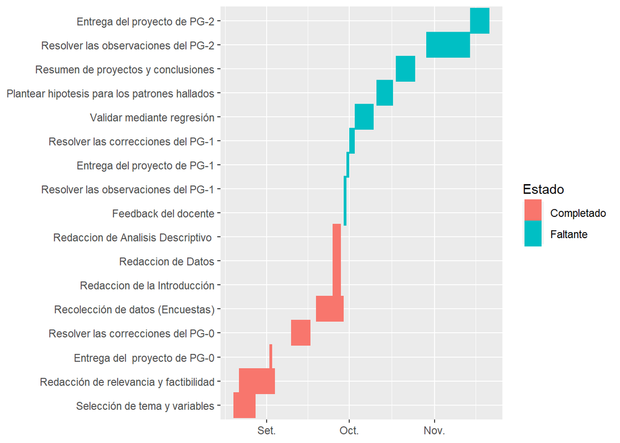

```r
actis <- c("Selección de tema y variables","Redacción de relevancia y factibilidad","Entrega del  proyecto de PG-0" ,"Resolver las correcciones del PG-0" ,"Recolección de datos (Encuestas)" ,"Redaccion de la Introducción" ,"Redaccion de Datos","Redaccion de Analisis Descriptivo ","Feedback del docente","Resolver las observaciones del PG-1","Entrega del proyecto de PG-1","Resolver las correcciones del PG-1","Validar mediante regresión","Plantear hipotesis para los patrones hallados","Resumen de proyectos y conclusiones","Resolver las observaciones del PG-2","Entrega del proyecto de PG-2")
gantt <- data.frame(
  name        = factor(actis, levels = actis),
  start.date  = as.Date(c("2022-08-20","2022-08-22", "2022-09-02", "2022-09-10", "2022-09-19", "2022-09-25","2022-09-25","2022-09-25","2022-09-29","2022-09-29","2022-09-30","2022-10-01","2022-10-03","2022-10-11","2022-10-18","2022-10-29","2022-11-14")),
  end.date    = as.Date(c("2022-08-28","2022-09-04", "2022-09-03", "2022-09-17", "2022-09-29", "2022-09-28","2022-09-28","2022-09-28","2022-09-30","2022-09-30","2022-10-01","2022-10-03","2022-10-10","2022-10-17","2022-10-25","2022-11-14","2022-11-21")),
  Estado = c("Completado", "Completado", "Completado", "Completado","Completado", "Completado", "Completado","Completado","Faltante","Faltante","Faltante","Faltante","Faltante","Faltante","Faltante","Faltante","Faltante")
)

ggplot(gantt, aes(x =start.date, xend= end.date, y=name, yend = name, color=Estado)) +
  geom_segment(size = 10) +
  xlab(NULL) + ylab(NULL)
```

Diagrama de Gantt

## ¿Es el estudio de interés para la audiencia?

El tiempo de movilización es un factor importante para todos los estudiantes universitarios, porque permite organizar su tiempo para realizar todas las actividades planteadas en el día, su horario de estudio, verificar el tiempo que emplean para llegar a sus clases presenciales y volver a casa, además de la carga emocional que aporta.

## ¿Qué información se desea aportar al final del estudio?

El propósito del estudio es determinar la porción de alumnos que emplean mayor tiempo para movilizarse, qué tipo de transporte usan ,el gasto que esto les genera y el nivel de estrés que aporta.

## ¿Es posible llegar a la información que se propone de manera específica y concreta?

Es posible llegar a dicha información, para recopilar los datos haremos uso de la encuesta. Crearemos la encuesta en google forms para obtener datos reales y verdaderos, así mismo usaremos el programa RStudio para facilitar el desarrollo de la investigación,con el fin de brindar información clara, concisa y entendible.

## Factibilidad

La recolección de datos del presente estudio se realizará utilizando el método de encuestas. Se creará un instrumento de recolección mediante la aplicación de un Google Forms. Además, este aplicativo nos permitirá generar las preguntas necesarias y pertinentes para la recolección. Luego, se compartirá y difundirá el enlace generado en el google forms para que los estudiantes del Campus puedan llenarlo. La recolección de datos tendrá un tiempo límite máximo de dos semanas con un mínimo de 200 observaciones.

# Datos

## Proceso de recolección de datos

- **Búsqueda de un instrumento de recolección:** Inicialmente se realizó la búsqueda de un instrumento para la recolección de los 204 datos del proyecto. En nuestro caso, implementamos la herramienta de Google Forms. Ya que, esta plataforma al ser de uso gratuito nos ayudó desarrollar las encuestas de manera factible y dinámica. Asimismo, la plataforma nos permitió descargar los datos en formato .csv para trabajarlo posteriormente en R- Studio.
- **Condiciones para la recolección:** Las encuestas fueron limitadas, ya que solo se realizaron a los estudiantes de UTEC. Sin embargo, no se consideró un rango de edad límite o específico, el único requisito era estar cursando algún ciclo de manera activa.
- **Formulación de las preguntas:** Mediante la plataforma zoom se realizaron reuniones de equipo para formular las preguntas correspondientes que irían en el instrumento de recolección previamente mencionado. Asimismo, cada pregunta se hizo tomando en consideración la relevancia de las variables en estudio para nuestro proyecto.
- **Estrategia de incentivo para la recolección:** El equipo consideró factible realizar un sorteo virtual de 2 combos de la empresa peruana Bembos como un incentivo para los encuestados. La fecha y hora del sorteo fue programada por los mismos integrantes del proyecto. Otra estrategia de respuesta inmediata fue la de entregar un chupetín a cambio de rellenar la encuesta, este método se hizo de manera presencial y la premiación fue inmediata.
- **Difusión de las encuestas por la modalidad virtual:** El link de la encuesta se difundió por las plataformas de WhatsApp, Telegram, Discord, etc.
- **Difusión de las encuestas por la modalidad presencial:** Se realizaron algunas encuestas de manera presencial en UTEC. Para ello se implemento el uso de un código QR, lo cual nos permitió compartir el enlace de la encuesta. Asimismo, se dio un pequeño dulce como incentivo hacia los encuestadores.

## Variables de estudio

| Variable | Tipo | Restricción |
| --- | --- | --- |
| Distrito de procedencia | Categórica nominal | Pregunta cerrada |
| Tipo de transporte | Categórica nominal | Pregunta cerrada |
| Tiempo de movilización | Cuantitativa continua | Entero positivo |
| Cantidad de transporte | Cuantitativa discreta | Entero positivo |
| Tiempo de caminata al paradero | Cuantitativa continua | Entero positivo |
| Pasatiempo en el transporte | Categórica nominal | Pregunta cerrada |
| Costo de la movilidad | Cuantitativa continua | Entero positivo |
| Nivel de estrés | Categórica ordinal | Pregunta cerrada |
| Sexo | Categórica nominal | Pregunta cerrada |
| Edad | Categórica nominal | Entero positivo |
| Nombre | Categórica nominal | Pregunta abierta |
| Código | Categórica nominal | Pregunta abierta |
| Ciclo | Categórica ordinal | Entero positivo |

## Limpieza de base de datos

### Dimension de la base de datos y tipos de variables

```r
glimpse(DE)
```

```
## Rows: 204
## Columns: 16
## $ `Marca temporal`                                                                                                                                   <chr> ~
## $ `Dirección de correo electrónico`                                                                                                                  <chr> ~
## $ `Nombres y Apellidos`                                                                                                                              <chr> ~
## $ `Código UTEC`                                                                                                                                      <dbl> ~
## $ Ciclo                                                                                                                                              <dbl> ~
## $ Carrera                                                                                                                                            <chr> ~
## $ `¿Cuántos años tienes? (Ejemplo: 20)`                                                                                                              <dbl> ~
## $ Sexo                                                                                                                                               <chr> ~
## $ `¿En qué distrito vives?`                                                                                                                          <chr> ~
## $ `¿Qué medio(os) de transporte usas para llegar al campus de UTEC?`                                                                                 <chr> ~
## $ `¿Cuántos medios de transporte usas para llegar a la universidad? (Ejemplo: 2)`                                                                    <dbl> ~
## $ `Desde que sales de tu casa hasta llegar a la universidad, ¿cuánto tiempo a transcurrido? Si seleccionas otro, ingresa un número entero en horas.` <chr> ~
## $ `¿Aproximadamente cuánto tiempo caminas?(Para llegar al paradero (os) y a la universidad) Ingresa un número entero en minutos`                     <dbl> ~
## $ `¿Cómo matas el rato en el transporte público?`                                                                                                    <chr> ~
## $ `Al día, ¿Cuánto gastas para movilizarte de tu casa a la universidad? Ida y vuelta. (Sólo escribe un número entero)`                               <dbl> ~
## $ `Nivel de estrés en el transporte público (Siendo 1 muy poco y 5 demasiado)`                                                                       <dbl> ~
```

- **Comentario**  
  Se utilizó el comando “glimpse” para poder conocer el numero de columnas(variables) y filas(objetos). Asimismo, conocer los nombres de las variables y el tipo de variable que es.

### cambio de variables CORRECTA

```r
library(dplyr)
BDC<-read_csv("EHT-Respuestas.csv", col_types = "ccciicicccidicii")
glimpse(BDC)
```

```
## Rows: 204
## Columns: 16
## $ `Marca temporal`                                                                                                                                   <chr> ~
## $ `Dirección de correo electrónico`                                                                                                                  <chr> ~
## $ `Nombres y Apellidos`                                                                                                                              <chr> ~
## $ `Código UTEC`                                                                                                                                      <int> ~
## $ Ciclo                                                                                                                                              <int> ~
## $ Carrera                                                                                                                                            <chr> ~
## $ `¿Cuántos años tienes? (Ejemplo: 20)`                                                                                                              <int> ~
## $ Sexo                                                                                                                                               <chr> ~
## $ `¿En qué distrito vives?`                                                                                                                          <chr> ~
## $ `¿Qué medio(os) de transporte usas para llegar al campus de UTEC?`                                                                                 <chr> ~
## $ `¿Cuántos medios de transporte usas para llegar a la universidad? (Ejemplo: 2)`                                                                    <int> ~
## $ `Desde que sales de tu casa hasta llegar a la universidad, ¿cuánto tiempo a transcurrido? Si seleccionas otro, ingresa un número entero en horas.` <dbl> ~
## $ `¿Aproximadamente cuánto tiempo caminas?(Para llegar al paradero (os) y a la universidad) Ingresa un número entero en minutos`                     <int> ~
## $ `¿Cómo matas el rato en el transporte público?`                                                                                                    <chr> ~
## $ `Al día, ¿Cuánto gastas para movilizarte de tu casa a la universidad? Ida y vuelta. (Sólo escribe un número entero)`                               <int> ~
## $ `Nivel de estrés en el transporte público (Siendo 1 muy poco y 5 demasiado)`                                                                       <int> ~
```

- **Comentario**  
  En este paso se identificó los tipos de variables, encontrando algunas variables con el tipo mal asignado, por ello se procedió a asignarles el correcto tipo a cada variable, para ello utilizamos “col_types”

### Eliminación de datos innecesarios como “Marca temporal” y Direccion de “correo”

```r
BD<- DE [,-1]
BD<- BD [,-1]
BD
```

| Nombres y Apellidos | Código UTEC | Ciclo | Carrera | ¿Cuántos años tienes? (Ejemplo: 20) | Sexo | ¿En qué distrito vives? | ¿Qué medio(os) de transporte usas para llegar al campus de UTEC? | ¿Cuántos medios de transporte usas para llegar a la universidad? (Ejemplo: 2) | Desde que sales de tu casa hasta llegar a la universidad, ¿cuánto tiempo a transcurrido? Si seleccionas otro, ingresa un número entero en horas. | ¿Aproximadamente cuánto tiempo caminas?(Para llegar al paradero (os) y a la universidad) Ingresa un número entero en minutos | ¿Cómo matas el rato en el transporte público? | Al día, ¿Cuánto gastas para movilizarte de tu casa a la universidad? Ida y vuelta. (Sólo escribe un número entero) | Nivel de estrés en el transporte público (Siendo 1 muy poco y 5 demasiado) |
| --- | --- | --- | --- | --- | --- | --- | --- | --- | --- | --- | --- | --- | --- |
| Daniel Ticona | 202020154 | 5 | Ingeniería Civil | 21 | Masculino | San Juan de Miraflores | Micro, Combi | 2 | De 1 a 1 (1/2) hora. | 5 | Repasar tus clases | 5 | 4 |
| Fátima Rosmery Jara Cuya | 202120301 | 3 | Bioingeniería | 19 | Femenino | Ate vitarte | Metropolitano, Combi, Corredor rojo | 3 | Entre 2 a 3 horas | 3 | Dormir | 7 | 3 |
| Marieta Graciela Campoblanco Carhuachin | 202120127 | 3 | Ingeniería de la Energía | 19 | Femenino | San Martín de Porres | Metropolitano, Combi | 2 | 2 horas | 15 | Redes sociales | 9 | 3 |
| Pilar Esmeralda Soto Poma | 202120551 | 3 | Ingeniería Química | 19 | Femenino | Barranco | caminando | 0 | Entre 15 a 30 min. | 20 | Caminar | 0 | 2 |
| Edid Jackerine Gallardo Villa | 202120226 | 3 | Ingeniería Industrial | 17 | Femenino | Lima | Metropolitano | 1 | Entre 30 min. a 1 hora. | 10 | Leer (novelas, cómics) | 3 | 3 |
| Thalia Palomino | 202120419 | 3 | Ingeniería Industrial | 20 | Femenino | El Agustino | Corredor azul, Combi | 2 | 2 horas | 10 | Repasar tus clases | 7 | 4 |
| Niunier David Briceño León | 202120111 | 3 | Ingeniería Industrial | 19 | Masculino | Barranco | Corredor azul, Micro | 2 | Entre 15 a 30 min. | 1 | Redes sociales | 2 | 3 |
| Jackelin Yesenia Guzman Baños | 202020080 | 5 | Ingeniería Civil | 21 | Femenino | Villa María del Triunfo | Tren eléctrico, Combi | 2 | 2 horas | 15 | Dormir | 7 | 4 |
| Andrea Del Carmen Montes Rosales | 202120381 | 3 | Ingeniería Industrial | 20 | Femenino | Pachacamac | Micro, Combi | 2 | 2 horas | 25 | Dormir | 10 | 4 |
| Araceli Cunza Manrique | 202120187 | 3 | Ingeniería Química | 19 | Femenino | Puente Piedra | Metropolitano, Combi, Corredor azul | 3 | 2 horas | 10 | Redes sociales | 8 | 4 |

[output cut: 194 more lines]

- **Comentario**  
  Hallamos variables innecesarias para nuestro estudio así que se procedió a eliminar dichas variables con la finalidad de tener una base de datos compacta.

### Datos completos /Datos incompletos

```r
sum(!is.na(BD)) #COMPLETOS
```

```
## [1] 2856
```

```r
sum(is.na(BD))  #INCOMPLETOS
```

```
## [1] 0
```

### Casos completos / incompletos

```r
sum(complete.cases(BD)) #complete.cases -> casos completos
```

```
## [1] 204
```

```r
sum(!complete.cases(BD))#!complete.cases -> casos incompletos
```

```
## [1] 0
```

Hay 204 filas completas hay 0 filas incompletas

Leer los nombres de las variables:

```r
names(BD)
```

```
##  [1] "Nombres y Apellidos"
##  [2] "Código UTEC"
##  [3] "Ciclo"
##  [4] "Carrera"
##  [5] "¿Cuántos años tienes? (Ejemplo: 20)"
##  [6] "Sexo"
##  [7] "¿En qué distrito vives?"
##  [8] "¿Qué medio(os) de transporte usas para llegar al campus de UTEC?"
##  [9] "¿Cuántos medios de transporte usas para llegar a la universidad? (Ejemplo: 2)"
## [10] "Desde que sales de tu casa hasta llegar a la universidad, ¿cuánto tiempo a transcurrido? Si seleccionas otro, ingresa un número entero en horas."
## [11] "¿Aproximadamente cuánto tiempo caminas?(Para llegar al paradero (os) y a la universidad) Ingresa un número entero en minutos"
## [12] "¿Cómo matas el rato en el transporte público?"
## [13] "Al día, ¿Cuánto gastas para movilizarte de tu casa a la universidad? Ida y vuelta. (Sólo escribe un número entero)"
## [14] "Nivel de estrés en el transporte público (Siendo 1 muy poco y 5 demasiado)"
```

- **Comentario** Se utilizo el comando “names” para poder leer los nombres de las variables de la base de datos.

### Renombramos las columnas

```r
BDC <- rename(BD, Nombres= 'Nombres y Apellidos', Codigo= 'Código UTEC', Edad = '¿Cuántos años tienes? (Ejemplo: 20)', Distrito= '¿En qué distrito vives?', Transporte= '¿Qué medio(os) de transporte usas para llegar al campus de UTEC?', Buses= '¿Cuántos medios de transporte usas para llegar a la universidad? (Ejemplo: 2)', Tiempo= 'Desde que sales de tu casa hasta llegar a la universidad, ¿cuánto tiempo a transcurrido? Si seleccionas otro, ingresa un número entero en horas.', Caminata= '¿Aproximadamente cuánto tiempo caminas?(Para llegar al paradero (os) y a la universidad) Ingresa un número entero en minutos', Desaburrimiento= '¿Cómo matas el rato en el transporte público?', Gasto= 'Al día, ¿Cuánto gastas para movilizarte de tu casa a la universidad? Ida y vuelta. (Sólo escribe un número entero)', Estrés= 'Nivel de estrés en el transporte público (Siendo 1 muy poco y 5 demasiado)' )
```

- **Comentario**  
  Hemos visto por conveniente asignarles un nuevo nombre a cada variable, para poder trabajar mejor y nos facilite su identificación, para realizar este paso hemos utilizado la herramienta “rename”.

```r
names(BDC)
```

```
##  [1] "Nombres"         "Codigo"          "Ciclo"           "Carrera"
##  [5] "Edad"            "Sexo"            "Distrito"        "Transporte"
##  [9] "Buses"           "Tiempo"          "Caminata"        "Desaburrimiento"
## [13] "Gasto"           "Estrés"
```

- **Comentario**  
  Acá podemos observar los nuevos nombres asignados a las variables.

```r
BDC
```

| Nombres | Codigo | Ciclo | Carrera | Edad | Sexo | Distrito | Transporte | Buses | Tiempo | Caminata | Desaburrimiento | Gasto | Estrés |
| --- | --- | --- | --- | --- | --- | --- | --- | --- | --- | --- | --- | --- | --- |
| Daniel Ticona | 202020154 | 5 | Ingeniería Civil | 21 | Masculino | San Juan de Miraflores | Micro, Combi | 2 | De 1 a 1 (1/2) hora. | 5 | Repasar tus clases | 5 | 4 |
| Fátima Rosmery Jara Cuya | 202120301 | 3 | Bioingeniería | 19 | Femenino | Ate vitarte | Metropolitano, Combi, Corredor rojo | 3 | Entre 2 a 3 horas | 3 | Dormir | 7 | 3 |
| Marieta Graciela Campoblanco Carhuachin | 202120127 | 3 | Ingeniería de la Energía | 19 | Femenino | San Martín de Porres | Metropolitano, Combi | 2 | 2 horas | 15 | Redes sociales | 9 | 3 |
| Pilar Esmeralda Soto Poma | 202120551 | 3 | Ingeniería Química | 19 | Femenino | Barranco | caminando | 0 | Entre 15 a 30 min. | 20 | Caminar | 0 | 2 |
| Edid Jackerine Gallardo Villa | 202120226 | 3 | Ingeniería Industrial | 17 | Femenino | Lima | Metropolitano | 1 | Entre 30 min. a 1 hora. | 10 | Leer (novelas, cómics) | 3 | 3 |
| Thalia Palomino | 202120419 | 3 | Ingeniería Industrial | 20 | Femenino | El Agustino | Corredor azul, Combi | 2 | 2 horas | 10 | Repasar tus clases | 7 | 4 |
| Niunier David Briceño León | 202120111 | 3 | Ingeniería Industrial | 19 | Masculino | Barranco | Corredor azul, Micro | 2 | Entre 15 a 30 min. | 1 | Redes sociales | 2 | 3 |
| Jackelin Yesenia Guzman Baños | 202020080 | 5 | Ingeniería Civil | 21 | Femenino | Villa María del Triunfo | Tren eléctrico, Combi | 2 | 2 horas | 15 | Dormir | 7 | 4 |
| Andrea Del Carmen Montes Rosales | 202120381 | 3 | Ingeniería Industrial | 20 | Femenino | Pachacamac | Micro, Combi | 2 | 2 horas | 25 | Dormir | 10 | 4 |
| Araceli Cunza Manrique | 202120187 | 3 | Ingeniería Química | 19 | Femenino | Puente Piedra | Metropolitano, Combi, Corredor azul | 3 | 2 horas | 10 | Redes sociales | 8 | 4 |

[output cut: 194 more lines]

### Ciclo

```r
ciclo <- select(BDC,Ciclo)
ciclo %>%
  group_by(Ciclo) %>%
  summarise(n = n()) %>%
  mutate(proporcion = n / sum(n), porciento = proporcion*100)
```

| Ciclo | n | proporcion | porciento |
| --- | --- | --- | --- |
| 1 | 26 | 0.12745098 | 12.745098 |
| 2 | 32 | 0.15686275 | 15.686275 |
| 3 | 87 | 0.42647059 | 42.647059 |
| 4 | 25 | 0.12254902 | 12.254902 |
| 5 | 14 | 0.06862745 | 6.862745 |
| 6 | 6 | 0.02941176 | 2.941176 |
| 7 | 3 | 0.01470588 | 1.470588 |
| 8 | 7 | 0.03431373 | 3.431373 |
| 9 | 4 | 0.01960784 | 1.960784 |

- **Interpretación** El menor ciclo en el que se encuentran estudiantes encuestados es en el ciclo 1. El mayor ciclo en el que se encuentran estudiantes encuestados es en el ciclo 9. La mayoría de los encuestados están cursando el ciclo 3 con 42.64%.
- **Comentario** Se utilizó el comando “group_by” para agrupar una columna, el comando “summarise” para crear una nueva data frame complementando con el comando “mutate”.

### Carrera

```r
carrera <- select(BDC,Carrera)
carrera %>%
  group_by(Carrera) %>%
  summarise(n = n()) %>%
  mutate(proporcion = n / sum(n), porciento = proporcion*100)
```

| Carrera | n | proporcion | porciento |
| --- | --- | --- | --- |
| Administración y Negocios Digitales | 7 | 0.034313725 | 3.4313725 |
| Bioingeniería | 35 | 0.171568627 | 17.1568627 |
| Ciencia de Datos | 1 | 0.004901961 | 0.4901961 |
| Ciencia de la Computación | 20 | 0.098039216 | 9.8039216 |
| Ingeniería Ambiental | 14 | 0.068627451 | 6.8627451 |
| Ingeniería Civil | 26 | 0.127450980 | 12.7450980 |
| Ingeniería Electronica | 5 | 0.024509804 | 2.4509804 |
| Ingeniería Industrial | 24 | 0.117647059 | 11.7647059 |
| Ingeniería Mecatrónica | 24 | 0.117647059 | 11.7647059 |
| Ingeniería Mecánica | 10 | 0.049019608 | 4.9019608 |

[output cut: 2 more lines]

- **Interpretación** De nuestra muestra de 204 estudiantes de UTEC, en su mayoría 35 estudian la carrera de Bioingeniería con 17.15%. En su minoría Ciencia de Datos CON 0.49%.

### Edad

```r
edad <- select(BDC,Edad)
edad %>%
  group_by(Edad) %>%
  summarise(n = n()) %>%
  mutate(proporcion = n / sum(n), porciento = proporcion*100)
```

| Edad | n | proporcion | porciento |
| --- | --- | --- | --- |
| 17 | 32 | 0.156862745 | 15.6862745 |
| 18 | 43 | 0.210784314 | 21.0784314 |
| 19 | 57 | 0.279411765 | 27.9411765 |
| 20 | 33 | 0.161764706 | 16.1764706 |
| 21 | 16 | 0.078431373 | 7.8431373 |
| 22 | 9 | 0.044117647 | 4.4117647 |
| 23 | 6 | 0.029411765 | 2.9411765 |
| 24 | 3 | 0.014705882 | 1.4705882 |
| 25 | 1 | 0.004901961 | 0.4901961 |
| 27 | 2 | 0.009803922 | 0.9803922 |

[output cut: 2 more lines]

```r
#summary(BDC$Edad)
#table(GP$Edad)
```

- **Interpretación** La edad mínima de los estudiantes encuestados es 17 años con 15.68%. La edad máxima de los estudiantes encuestados es 33 años con 0.49%. La edad promedio es 19.34 años de los estudiantes encuestados.

La edad mas frecuente es 19 años entre los estudiantes encuestados y se repite 57 veces siendo el 27.94% del total.

### Descriptores numericos - Edad

```r
var(BDC$Edad,na.rm=T)  # varianza
```

```
## [1] 4.709263
```

```r
sd(BDC$Edad,na.rm=T)   # desviación estándar
```

```
## [1] 2.170084
```

```r
range(BDC$Edad) #RANGO
```

```
## [1] 17 33
```

```r
mean(BDC$Edad,na.rm=T)  # la media o promedio ( esto no mide la dispersión)
```

```
## [1] 19.34314
```

```r
CV<-(sd(BDC$Edad,na.rm=T)/mean(BDC$Edad,na.rm=T))*100   # coeficiente de variación.
CV
```

```
## [1] 11.21888
```

- **Interpretación:**
  - Tenemos como varianza un valor de 4.709.
  - Tenemos un valor de desviación estándar de 2.17.
  - Tenemos edades en un rango desde 17 hasta 33 años de edad.
  - Tenemos un promedio de edad de 19 años.
  - Tenemos un coeficiente de variación de 11.219.

### Sexo

```r
sex <- select(BDC,Sexo)
sex %>%
  group_by(Sexo) %>%
  summarise(n = n()) %>%
  mutate(proporcion = n / sum(n), porciento = proporcion*100)
```

| Sexo | n | proporcion | porciento |
| --- | --- | --- | --- |
| Femenino | 95 | 0.465686275 | 46.5686275 |
| Masculino | 107 | 0.524509804 | 52.4509804 |
| Prefiero no decirlo | 2 | 0.009803922 | 0.9803922 |

### Distrito

```r
#dis<-c(table(BDC$Distrito))
#View(dis)
distr <- select(BDC,Distrito)
distr %>%
  group_by(Distrito) %>%
  summarise(n = n()) %>%
  mutate(proporcion = n / sum(n), porciento = proporcion*100)
```

| Distrito | n | proporcion | porciento |
| --- | --- | --- | --- |
| Ancón | 1 | 0.004901961 | 0.4901961 |
| Ate vitarte | 6 | 0.029411765 | 2.9411765 |
| Barranco | 27 | 0.132352941 | 13.2352941 |
| Breña | 1 | 0.004901961 | 0.4901961 |
| Carabayllo | 4 | 0.019607843 | 1.9607843 |
| Chorrillos | 16 | 0.078431373 | 7.8431373 |
| Cieneguilla | 1 | 0.004901961 | 0.4901961 |
| Comas | 9 | 0.044117647 | 4.4117647 |
| El Agustino | 4 | 0.019607843 | 1.9607843 |
| Independencia | 1 | 0.004901961 | 0.4901961 |

[output cut: 25 more lines]

- **Interpretación** La mayoría de los estudiantes encuestados se encuentran residiendo en el Distrito de Barranco (27) siendo este un 13.23% del total. La minoría de los estudiantes encuestados se encuentran residiendo en los Distrito de Ancón, Cieneguilla, Pachacamac, Breña, Independencia, Jesus María y San Miguel con un 0.49%.

### Transporte

```r
trans <- select(BDC,Transporte)
trans %>%
  group_by(Transporte) %>%
  summarise(n = n()) %>%
  mutate(proporcion = n / sum(n), porciento = proporcion*100)
```

| Transporte | n | proporcion | porciento |
| --- | --- | --- | --- |
| Auto de mi papá | 1 | 0.004901961 | 0.4901961 |
| Bici | 2 | 0.009803922 | 0.9803922 |
| Bicicleta | 3 | 0.014705882 | 1.4705882 |
| Caminando | 15 | 0.073529412 | 7.3529412 |
| Carro propio | 3 | 0.014705882 | 1.4705882 |
| Colectivo | 5 | 0.024509804 | 2.4509804 |
| Combi | 8 | 0.039215686 | 3.9215686 |
| Combi, Colectivo | 1 | 0.004901961 | 0.4901961 |
| Combi, Taxi | 1 | 0.004901961 | 0.4901961 |
| Corredor azul | 4 | 0.019607843 | 1.9607843 |

[output cut: 47 more lines]

- **Comentario**  
  En la tabla de transporte podemos ver los porcentajes de cada uno de los tipos de transporte que los estudiantes utilizan.

### Buses

```r
bus <- select(BDC,Buses)
bus %>%
  group_by(Buses) %>%
  summarise(n = n()) %>%
  mutate(proporcion = n / sum(n), porciento = proporcion*100)
```

| Buses | n | proporcion | porciento |
| --- | --- | --- | --- |
| 0 | 15 | 0.073529412 | 7.3529412 |
| 1 | 70 | 0.343137255 | 34.3137255 |
| 2 | 89 | 0.436274510 | 43.6274510 |
| 3 | 29 | 0.142156863 | 14.2156863 |
| 4 | 1 | 0.004901961 | 0.4901961 |

- **Interpretación** De nuestros encuestados en la mayoría el 43.62% utiliza 2 transportes para llegar a la universidad, y el 7.35% no utilizan transporte pues viven cerca a UTEC y vienen caminando.

### Tiempo de llegada a UTEC

```r
tim <- select(BDC,Tiempo)
tim %>%
  group_by(Tiempo) %>%
  summarise(n = n()) %>%
  mutate(proporcion = n / sum(n), porciento = proporcion*100)
```

| Tiempo | n | proporcion | porciento |
| --- | --- | --- | --- |
| 10 minutos | 1 | 0.004901961 | 0.4901961 |
| 10-15 min | 1 | 0.004901961 | 0.4901961 |
| 10min | 1 | 0.004901961 | 0.4901961 |
| 2 horas | 32 | 0.156862745 | 15.6862745 |
| 5 minutos | 1 | 0.004901961 | 0.4901961 |
| De 1 a 1 (1/2) hora. | 55 | 0.269607843 | 26.9607843 |
| Entre 15 a 30 min. | 48 | 0.235294118 | 23.5294118 |
| Entre 2 a 3 horas | 18 | 0.088235294 | 8.8235294 |
| Entre 30 min. a 1 hora. | 47 | 0.230392157 | 23.0392157 |

- **Interpretación** De nuestra muestra de encuestados 55 estudiantes los cuales representan l 26.96% demoran de 1 a 1 1/2 hora del paradero mas cercano de su domicilio a UTEC.

### Tiempo de caminata desde su casa al paradero mas cercano

```r
timc <- select(BDC,Caminata)
timc %>%
  group_by(Caminata) %>%
  summarise(n = n()) %>%
  mutate(proporcion = n / sum(n), porciento = proporcion*100)
```

| Caminata | n | proporcion | porciento |
| --- | --- | --- | --- |
| 0 | 8 | 0.039215686 | 3.9215686 |
| 1 | 6 | 0.029411765 | 2.9411765 |
| 2 | 7 | 0.034313725 | 3.4313725 |
| 3 | 3 | 0.014705882 | 1.4705882 |
| 4 | 2 | 0.009803922 | 0.9803922 |
| 5 | 37 | 0.181372549 | 18.1372549 |
| 6 | 1 | 0.004901961 | 0.4901961 |
| 7 | 8 | 0.039215686 | 3.9215686 |
| 8 | 5 | 0.024509804 | 2.4509804 |
| 9 | 1 | 0.004901961 | 0.4901961 |

[output cut: 7 more lines]

- **Interpretación** De nuestra muestra el 3.92% vive cerca a un paradero o tienen auto propio, el 26.47% el cual representa a la mayoría de estudiantes que demora 15 minutos en caminar al paradero mas cercano.

### Descriptores numericos - Caminata

```r
summary(BDC$Caminata)
```

```
##    Min. 1st Qu.  Median    Mean 3rd Qu.    Max.
##    0.00    5.00   10.00   10.07   15.00   25.00
```

```r
var(BDC$Caminata,na.rm=T)  # varianza
```

```
## [1] 31.12265
```

```r
sd(BDC$Caminata,na.rm=T)   # desviación estándar
```

```
## [1] 5.578767
```

```r
range(BDC$Caminata)   #rango
```

```
## [1]  0 25
```

```r
mean(BDC$Caminata,na.rm=T)  # la media o promedio ( esto no mide la dispersión)
```

```
## [1] 10.07353
```

```r
Cv<-(sd(BDC$Caminata,na.rm=T)/mean(BDC$Caminata,na.rm=T))*100   # coeficiente de variación.
Cv
```

```
## [1] 55.38046
```

- **Interpretación:**
  - Tenemos como varianza un valor de 31.123.
  - Tenemos un valor de desviación estándar de 5.579.
  - Tenemos un rango desde 0 hasta 25 minutos de caminata.
  - Tenemos un promedio de tiempo de 10.07 minutos.
  - Tenemos un coeficiente de variación de 55.38.

### Pasatiempo en el transporte

Limpieza de objetos en la variable

```r
unique(BDC$Desaburrimiento)
```

```
##  [1] "Repasar tus clases"     "Dormir"                 "Redes sociales"
##  [4] "Caminar"                "Leer (novelas, cómics)" "Solo caminar"
##  [7] "Escuchar música"        "Escuchar musica"        "Ecuchar musica"
## [10] "Música"                 "Escuchar podcast"       "Escucho música"
## [13] "Girar en circulos"      "Clash royale"           "Musica"
## [16] "Escuchar podcats"       "Escucho podcast"        "Jugar videojuegos"
```

Limpieza de la variable

```r
BDC<-mutate(BDC,Pasatiempo=case_when(Desaburrimiento == 'Ecuchar musica' ~'Escuchar música',Desaburrimiento == 'Escuchar música ' ~'Escuchar música',Desaburrimiento == 'Música ' ~'Escuchar música',Desaburrimiento == 'Escucho música ' ~'Escuchar música',Desaburrimiento == 'Musica' ~'Escuchar música',Desaburrimiento == 'Escuchar musica ' ~'Escuchar música',Desaburrimiento == 'Escuchar musica' ~'Escuchar música',Desaburrimiento == 'Escucho podcast' ~'Escuchar podcats',Desaburrimiento == 'Clash royale' ~'Jugar videojuegos',Desaburrimiento == 'Solo caminar' ~'Caminar',Desaburrimiento == 'Repasar tus clases' ~'Repasar',Desaburrimiento == 'Dormir' ~'Dormir',Desaburrimiento == 'Leer (novelas, cómics)' ~'Leer',Desaburrimiento == 'Girar en circulos' ~'Caminar',Desaburrimiento == 'Redes sociales' ~'Redes sociales',Desaburrimiento == 'Caminar' ~'Caminar',Desaburrimiento == 'Escuchar música' ~'Escuchar música',Desaburrimiento == 'Escuchar podcast' ~'Escuchar podcats',Desaburrimiento == 'Escuchar podcats' ~'Escuchar podcats',Desaburrimiento == 'Jugar videojuegos' ~'Jugar videojuegos'))

BDC
```

| Nombres | Codigo | Ciclo | Carrera | Edad | Sexo | Distrito | Transporte | Buses | Tiempo | Caminata | Desaburrimiento | Gasto | Estrés | Pasatiempo |
| --- | --- | --- | --- | --- | --- | --- | --- | --- | --- | --- | --- | --- | --- | --- |
| Daniel Ticona | 202020154 | 5 | Ingeniería Civil | 21 | Masculino | San Juan de Miraflores | Micro, Combi | 2 | De 1 a 1 (1/2) hora. | 5 | Repasar tus clases | 5 | 4 | Repasar |
| Fátima Rosmery Jara Cuya | 202120301 | 3 | Bioingeniería | 19 | Femenino | Ate vitarte | Metropolitano, Combi, Corredor rojo | 3 | Entre 2 a 3 horas | 3 | Dormir | 7 | 3 | Dormir |
| Marieta Graciela Campoblanco Carhuachin | 202120127 | 3 | Ingeniería de la Energía | 19 | Femenino | San Martín de Porres | Metropolitano, Combi | 2 | 2 horas | 15 | Redes sociales | 9 | 3 | Redes sociales |
| Pilar Esmeralda Soto Poma | 202120551 | 3 | Ingeniería Química | 19 | Femenino | Barranco | caminando | 0 | Entre 15 a 30 min. | 20 | Caminar | 0 | 2 | Caminar |
| Edid Jackerine Gallardo Villa | 202120226 | 3 | Ingeniería Industrial | 17 | Femenino | Lima | Metropolitano | 1 | Entre 30 min. a 1 hora. | 10 | Leer (novelas, cómics) | 3 | 3 | Leer |
| Thalia Palomino | 202120419 | 3 | Ingeniería Industrial | 20 | Femenino | El Agustino | Corredor azul, Combi | 2 | 2 horas | 10 | Repasar tus clases | 7 | 4 | Repasar |
| Niunier David Briceño León | 202120111 | 3 | Ingeniería Industrial | 19 | Masculino | Barranco | Corredor azul, Micro | 2 | Entre 15 a 30 min. | 1 | Redes sociales | 2 | 3 | Redes sociales |
| Jackelin Yesenia Guzman Baños | 202020080 | 5 | Ingeniería Civil | 21 | Femenino | Villa María del Triunfo | Tren eléctrico, Combi | 2 | 2 horas | 15 | Dormir | 7 | 4 | Dormir |
| Andrea Del Carmen Montes Rosales | 202120381 | 3 | Ingeniería Industrial | 20 | Femenino | Pachacamac | Micro, Combi | 2 | 2 horas | 25 | Dormir | 10 | 4 | Dormir |
| Araceli Cunza Manrique | 202120187 | 3 | Ingeniería Química | 19 | Femenino | Puente Piedra | Metropolitano, Combi, Corredor azul | 3 | 2 horas | 10 | Redes sociales | 8 | 4 | Redes sociales |

[output cut: 194 more lines]

```r
unique(BDC$Pasatiempo)
```

```
## [1] "Repasar"           "Dormir"            "Redes sociales"
## [4] "Caminar"           "Leer"              "Escuchar música"
## [7] NA                  "Escuchar podcats"  "Jugar videojuegos"
```

```r
des <- select(BDC,Pasatiempo)
des %>%
  group_by(Pasatiempo) %>%
  summarise(n = n()) %>%
  mutate(proporcion = n / sum(n), porciento = proporcion*100)
```

| Pasatiempo | n | proporcion | porciento |
| --- | --- | --- | --- |
| Caminar | 3 | 0.014705882 | 1.4705882 |
| Dormir | 39 | 0.191176471 | 19.1176471 |
| Escuchar música | 25 | 0.122549020 | 12.2549020 |
| Escuchar podcats | 3 | 0.014705882 | 1.4705882 |
| Jugar videojuegos | 2 | 0.009803922 | 0.9803922 |
| Leer | 23 | 0.112745098 | 11.2745098 |
| Redes sociales | 80 | 0.392156863 | 39.2156863 |
| Repasar | 25 | 0.122549020 | 12.2549020 |
| NA | 4 | 0.019607843 | 1.9607843 |

- **Interpretación**  
  De los encuestados, el 39.21% representado por 80 estudiantes encuestados matan el aburriendo viendo redes sociales en el transporte.

### Gasto diario

```r
gd <- select(BDC,Gasto)
gd %>%
  group_by(Gasto) %>%
  summarise(n = n()) %>%
  mutate(proporcion = n / sum(n), porciento = proporcion*100)
```

| Gasto | n | proporcion | porciento |
| --- | --- | --- | --- |
| 0 | 22 | 0.107843137 | 10.7843137 |
| 1 | 3 | 0.014705882 | 1.4705882 |
| 2 | 15 | 0.073529412 | 7.3529412 |
| 3 | 15 | 0.073529412 | 7.3529412 |
| 4 | 19 | 0.093137255 | 9.3137255 |
| 5 | 28 | 0.137254902 | 13.7254902 |
| 6 | 17 | 0.083333333 | 8.3333333 |
| 7 | 9 | 0.044117647 | 4.4117647 |
| 8 | 14 | 0.068627451 | 6.8627451 |
| 9 | 4 | 0.019607843 | 1.9607843 |

[output cut: 11 more lines]

- **Interpretación** En la mayoría de encuestados el 13.72% representado por 28 estudiantes gasta 5 soles diario en transporte. Así mismo un 10.78% representado por 22 estudiantes n gasta en transporte. El mínimo gasto de transporte es de 1 nuevo sol (1.47%) y el máximo gasto es de 50 soles (0.98%).

### Nivel de estrés

```r
nd <- select(BDC,Estrés)
nd %>%
  group_by(Estrés) %>%
  summarise(n = n()) %>%
  mutate(proporcion = n / sum(n), porciento = proporcion*100)
```

| Estrés | n | proporcion | porciento |
| --- | --- | --- | --- |
| 1 | 12 | 0.05882353 | 5.882353 |
| 2 | 18 | 0.08823529 | 8.823529 |
| 3 | 66 | 0.32352941 | 32.352941 |
| 4 | 75 | 0.36764706 | 36.764706 |
| 5 | 33 | 0.16176471 | 16.176471 |

- **Interpretación**  
  El 36.76% de los estudiantes encuestados, califican su nivel de estrés con 4 de 5.

### FILTRO DE TRANSPORTES QUE UTILIZAN LOS ESTUDIANTES ENCUESTADOS

```r
#Veamos el nombres o respuestas diferentes de la variable Transporte con el comando unique.
unique(BDC$Transporte)
```

```
##  [1] "Micro, Combi"
##  [2] "Metropolitano, Combi, Corredor rojo"
##  [3] "Metropolitano, Combi"
##  [4] "caminando"
##  [5] "Metropolitano"
##  [6] "Corredor azul, Combi"
##  [7] "Corredor azul, Micro"
##  [8] "Tren eléctrico, Combi"
##  [9] "Metropolitano, Combi, Corredor azul"
## [10] "Micro"
## [11] "Caminando"
## [12] "Micro, Combi, Taxi"
## [13] "Corredor azul"
## [14] "Bici"
## [15] "Tren eléctrico, Micro, Taxi"
```

[output cut: 42 more lines]

### Estudiantes que utilizan Tren Eléctrico (“tren”)

```r
filter_tren<-filter(BDC, Transporte=="Tren eléctrico"|Transporte=="Tren eléctrico, Combi"|Transporte=="Tren eléctrico, Micro, Taxi"|Transporte=="Tren eléctrico, combi"|Transporte=="Tren eléctrico, Micro, Combi"|Transporte=="Tren eléctrico, Micro, Mototaxi"|Transporte=="Tren eléctrico,Micro"|Transporte=="Tren eléctrico, Micro, Colectivo"|Transporte=="Tren eléctrico, Micro"|Transporte=="Tren eléctrico, Micro, mototaxi"|Transporte=="Tren eléctrico, Metropolitano, Micro, Taxi"|Transporte=="Tren eléctrico"|Transporte=="Tren eléctrico, Metropolitano, Combi"|Transporte=="Tren eléctrico, Micro")
filter_tren
```

| Nombres | Codigo | Ciclo | Carrera | Edad | Sexo | Distrito | Transporte | Buses | Tiempo | Caminata | Desaburrimiento | Gasto | Estrés | Pasatiempo |
| --- | --- | --- | --- | --- | --- | --- | --- | --- | --- | --- | --- | --- | --- | --- |
| Jackelin Yesenia Guzman Baños | 202020080 | 5 | Ingeniería Civil | 21 | Femenino | Villa María del Triunfo | Tren eléctrico, Combi | 2 | 2 horas | 15 | Dormir | 7 | 4 | Dormir |
| Melany Paloma Vera Mejia | 202120652 | 3 | Ingeniería Química | 18 | Femenino | San Juan de Lurigancho | Tren eléctrico, Micro, Taxi | 3 | De 1 a 1 (1/2) hora. | 15 | Dormir | 8 | 5 | Dormir |
| Renato Vincenzo Moreno Amoretti | 202210214 | 2 | Ingeniería Química | 17 | Masculino | San Juan de Lurigancho | Tren eléctrico, combi | 2 | De 1 a 1 (1/2) hora. | 20 | Redes sociales | 4 | 5 | Redes sociales |
| Edwin Faed Risco Vasquez | 202210585 | 2 | Ingeniería Civil | 18 | Masculino | San Juan de Lurigancho | Tren eléctrico, Micro, Combi | 3 | 2 horas | 7 | Redes sociales | 10 | 4 | Redes sociales |
| Maria Dayana Gutierrez Huachopoma | 202220141 | 1 | Ciencia de la Computación | 21 | Femenino | Lima | Tren eléctrico, Micro, Mototaxi | 3 | Entre 2 a 3 horas | 8 | Dormir | 11 | 4 | Dormir |
| Abigail Shayumy Toscano Tapia | 202120574 | 3 | Ingeniería Industrial | 20 | Femenino | San Juan de Lurigancho | Tren eléctrico, Micro, Taxi | 3 | De 1 a 1 (1/2) hora. | 10 | Leer (novelas, cómics) | 12 | 5 | Leer |
| Daniel Villanueva Palomino | 202120605 | 3 | Ingeniería Industrial | 20 | Masculino | San Juan de Lurigancho | Tren eléctrico, Micro, Colectivo | 3 | De 1 a 1 (1/2) hora. | 10 | Leer (novelas, cómics) | 6 | 3 | Leer |
| Odaliz Amedaly Zanabria Huamán | 202020177 | 5 | Ingeniería Química | 19 | Femenino | San Juan de Lurigancho | Tren eléctrico, Micro | 2 | De 1 a 1 (1/2) hora. | 15 | Leer (novelas, cómics) | 8 | 3 | Leer |
| Evelyn Clara Sarmiento Zubilete | 202220093 | 1 | Ingeniería de la Energía | 20 | Femenino | San Juan de Lurigancho | Tren eléctrico, Micro, mototaxi | 3 | 2 horas | 5 | Repasar tus clases | 10 | 4 | Repasar |
| Diego Armando Valenzuela Huamán | 202210361 | 2 | Ingeniería Mecatrónica | 17 | Masculino | San Juan de Lurigancho | Tren eléctrico, Metropolitano, Micro, Taxi | 2 | Entre 2 a 3 horas | 10 | Ecuchar musica | 12 | 5 | Escuchar música |

[output cut: 10 more lines]

```r
nrow(filter_tren)
```

```
## [1] 20
```

### Estudiantes que utilizan Corredor Azul (“CA”)

```r
filter_CA<-filter(BDC, Transporte=="Corredor azul, Combi"|Transporte=="Corredor azul, Micro"|Transporte=="Metropolitano, Combi, Corredor azul"|Transporte=="Corredor azul"|Transporte=="Corredor azul, Metropolitano"|Transporte=="Corredor azul, Metropolitano, Colectivo"|Transporte=="Corredor azul, Micro, Combi"|Transporte=="Corredor azul, Metropolitano, Micro"|Transporte=="Corredor azul, Metropolitano, Taxi")
filter_CA
```

| Nombres | Codigo | Ciclo | Carrera | Edad | Sexo | Distrito | Transporte | Buses | Tiempo | Caminata | Desaburrimiento | Gasto | Estrés | Pasatiempo |
| --- | --- | --- | --- | --- | --- | --- | --- | --- | --- | --- | --- | --- | --- | --- |
| Thalia Palomino | 202120419 | 3 | Ingeniería Industrial | 20 | Femenino | El Agustino | Corredor azul, Combi | 2 | 2 horas | 10 | Repasar tus clases | 7 | 4 | Repasar |
| Niunier David Briceño León | 202120111 | 3 | Ingeniería Industrial | 19 | Masculino | Barranco | Corredor azul, Micro | 2 | Entre 15 a 30 min. | 1 | Redes sociales | 2 | 3 | Redes sociales |
| Araceli Cunza Manrique | 202120187 | 3 | Ingeniería Química | 19 | Femenino | Puente Piedra | Metropolitano, Combi, Corredor azul | 3 | 2 horas | 10 | Redes sociales | 8 | 4 | Redes sociales |
| Claudia Milagros Pacori Palomino | 201910250 | 8 | Ingeniería Electronica | 20 | Femenino | Jesus María | Corredor azul | 1 | De 1 a 1 (1/2) hora. | 10 | Redes sociales | 2 | 3 | Redes sociales |
| Antonio Jesús Romero Huamaní | 202210529 | 1 | Ingeniería Mecánica | 19 | Masculino | Ate vitarte | Corredor azul, Metropolitano | 2 | De 1 a 1 (1/2) hora. | 10 | Redes sociales | 4 | 2 | Redes sociales |
| Edgar Florencio Herrera Huamán | 202110578 | 4 | Ingeniería Civil | 19 | Masculino | Barranco | Corredor azul | 1 | Entre 15 a 30 min. | 20 | Redes sociales | 4 | 3 | Redes sociales |
| Fabiola Talla Lozano | 202110360 | 3 | Ingeniería Industrial | 18 | Femenino | Rímac | Corredor azul, Micro | 2 | De 1 a 1 (1/2) hora. | 5 | Redes sociales | 10 | 3 | Redes sociales |
| Angela Leydi Aquino Hurtado | 202120085 | 3 | Ingeniería Química | 20 | Femenino | Ate vitarte | Corredor azul, Metropolitano | 3 | 2 horas | 15 | Leer (novelas, cómics) | 20 | 4 | Leer |
| Hugo Alberth Panez Quinto | 201810313 | 8 | Ingeniería Industrial | 20 | Masculino | La Molina | Corredor azul, Metropolitano, Colectivo | 2 | 2 horas | 10 | Redes sociales | 10 | 5 | Redes sociales |
| Josue Fernando Huamani Gamboa | 202020084 | 3 | Ingeniería Mecatrónica | 19 | Masculino | Lurigancho | Corredor azul, Micro, Combi | 3 | Entre 2 a 3 horas | 7 | Redes sociales | 11 | 3 | Redes sociales |

[output cut: 9 more lines]

- **Interpretación**  
  De nuestra nuestra de 204 estudiantes, 19 de ellos entre hombres y mujeres utilizan el corredor azul como uno de sus transportes.

### Estudiantes que utilizan METROPOLITANO (“M”)

```r
filter_M<-filter(BDC, Transporte=="Metropolitano, Combi, Corredor rojo "|Transporte=="Metropolitano, Combi"|Transporte=="Metropolitano"|Transporte=="Metropolitano, Combi, Corredor azul"|Transporte=="Metropolitano, Micro"|Transporte=="Corredor azul, Metropolitano"|Transporte=="Metropolitano, Colectivo"|Transporte=="Metropolitano, moto"|Transporte==" Metropolitano"|Transporte=="Metropolitano, Corredor rojo"|Transporte=="Corredor azul, Metropolitano, Colectivo"|Transporte=="Tren eléctrico, Metropolitano, Micro, Taxi"|Transporte=="Metropolitano, Taxi"|Transporte=="Metropolitano, Micro, Combi"|Transporte=="Metropolitano, Combi, mototaxi"|Transporte=="Metropolitano, Micro, Combi, Colectivo"|Transporte=="Metropolitano, Colectivo, Taxi"|Transporte=="Corredor azul, Metropolitano, Micro"|Transporte=="Tren eléctrico, Metropolitano, Combi"|Transporte=="Metropolitano, Combi, Taxi"|Transporte=="Corredor azul, Metropolitano, Taxi"|Transporte=="Metropolitano, Micro, Combi, Taxi"|Transporte=="Metropolitano, Alimentador del metropolitano "|Transporte=="Metropolitano, Micro, Carro particular "|Transporte=="Metropolitano, Micro, Taxi")
filter_M
```

| Nombres | Codigo | Ciclo | Carrera | Edad | Sexo | Distrito | Transporte | Buses | Tiempo | Caminata | Desaburrimiento | Gasto | Estrés | Pasatiempo |
| --- | --- | --- | --- | --- | --- | --- | --- | --- | --- | --- | --- | --- | --- | --- |
| Marieta Graciela Campoblanco Carhuachin | 202120127 | 3 | Ingeniería de la Energía | 19 | Femenino | San Martín de Porres | Metropolitano, Combi | 2 | 2 horas | 15 | Redes sociales | 9 | 3 | Redes sociales |
| Edid Jackerine Gallardo Villa | 202120226 | 3 | Ingeniería Industrial | 17 | Femenino | Lima | Metropolitano | 1 | Entre 30 min. a 1 hora. | 10 | Leer (novelas, cómics) | 3 | 3 | Leer |
| Araceli Cunza Manrique | 202120187 | 3 | Ingeniería Química | 19 | Femenino | Puente Piedra | Metropolitano, Combi, Corredor azul | 3 | 2 horas | 10 | Redes sociales | 8 | 4 | Redes sociales |
| Jesús Ricardo Carrillo Martínez | 201920110 | 7 | Ingeniería Civil | 21 | Masculino | Chorrillos | Metropolitano | 1 | Entre 30 min. a 1 hora. | 2 | Repasar tus clases | 4 | 2 | Repasar |
| Oriana tasharen Espinoza colmenarez | 202220112 | 1 | Bioingeniería | 18 | Femenino | San Martín de Porres | Metropolitano | 2 | Entre 30 min. a 1 hora. | 10 | Redes sociales | 5 | 4 | Redes sociales |
| Lorena Jazmin Asto Urbano | 202120097 | 3 | Ingeniería Ambiental | 19 | Femenino | Comas | Metropolitano, Combi | 2 | 2 horas | 20 | Dormir | 6 | 2 | Dormir |
| Mariangeles Jhaqueline Quispe Apaza | 202120463 | 3 | Ingeniería Química | 19 | Femenino | Comas | Metropolitano | 1 | De 1 a 1 (1/2) hora. | 15 | Redes sociales | 7 | 5 | Redes sociales |
| Levi Leiva Carrera | 202120317 | 3 | Ingeniería Mecánica | 19 | Masculino | Puente Piedra | Metropolitano, Combi | 2 | Entre 2 a 3 horas | 15 | Redes sociales | 3 | 4 | Redes sociales |
| Carlos Alonso Flores Panduro | 202020064 | 4 | Ciencia de la Computación | 20 | Masculino | San Martín de Porres | Metropolitano | 2 | 2 horas | 15 | Dormir | 4 | 4 | Dormir |
| Cinthya Samaniego Meza | 202120519 | 3 | Bioingeniería | 19 | Femenino | Ate vitarte | Metropolitano | 2 | 2 horas | 10 | Leer (novelas, cómics) | 8 | 4 | Leer |

[output cut: 79 more lines]

- **Interpretación**  
  De nuestra nuestra de 204 estudiantes, 89 de ellos entre hombres y mujeres utilizan el metroplitano como uno de sus transportes.

### Estudiantes que utilizan Microbus (“MC”)

```r
filter_MC<-filter(BDC,Transporte=="Micro, Combi"|Transporte=="Corredor azul, Micro"|Transporte=="Micro"|Transporte=="Micro, Combi, Taxi"|Transporte=="Tren eléctrico, Micro, Taxi"|Transporte=="Metropolitano, Micro"|Transporte=="Tren eléctrico, Micro, Combi"|Transporte=="Tren eléctrico, Micro, Mototaxi"|Transporte=="Tren eléctrico,Micro, "|Transporte=="Tren eléctrico, Micro, Colectivo"|Transporte== "Tren eléctrico, Micro"|Transporte=="Micro, Taxi"|Transporte=="Micro, "|Transporte=="Tren eléctrico, Metropolitano, Micro, Taxi"|Transporte=="Corredor azul, Micro, Combi"|Transporte=="Metropolitano, Micro, Combi"|Transporte=="Metropolitano, Micro, Combi, Colectivo"|Transporte=="Corredor azul, Metropolitano, Micro" |Transporte=="Metropolitano, Micro, Combi, Taxi"|Transporte=="Micro, Taxi, Auto personal"|Transporte=="Micro, Caminando"|Transporte== "Metropolitano, Micro, Carro particular "|Transporte=="Metropolitano, Micro, Taxi")
filter_MC
```

| Nombres | Codigo | Ciclo | Carrera | Edad | Sexo | Distrito | Transporte | Buses | Tiempo | Caminata | Desaburrimiento | Gasto | Estrés | Pasatiempo |
| --- | --- | --- | --- | --- | --- | --- | --- | --- | --- | --- | --- | --- | --- | --- |
| Daniel Ticona | 202020154 | 5 | Ingeniería Civil | 21 | Masculino | San Juan de Miraflores | Micro, Combi | 2 | De 1 a 1 (1/2) hora. | 5 | Repasar tus clases | 5 | 4 | Repasar |
| Niunier David Briceño León | 202120111 | 3 | Ingeniería Industrial | 19 | Masculino | Barranco | Corredor azul, Micro | 2 | Entre 15 a 30 min. | 1 | Redes sociales | 2 | 3 | Redes sociales |
| Andrea Del Carmen Montes Rosales | 202120381 | 3 | Ingeniería Industrial | 20 | Femenino | Pachacamac | Micro, Combi | 2 | 2 horas | 25 | Dormir | 10 | 4 | Dormir |
| Sonia Reymi Mejia Caicedo | 202120363 | 3 | Ingeniería Industrial | 21 | Femenino | Ancón | Micro | 1 | Entre 2 a 3 horas | 10 | Redes sociales | 16 | 3 | Redes sociales |
| Daniel Gonzalo Acevedo Esquivel | 201720026 | 5 | Ingeniería Química | 23 | Masculino | Pueblo Libre | Micro, Combi | 2 | De 1 a 1 (1/2) hora. | 25 | Redes sociales | 10 | 2 | Redes sociales |
| María de los Ángeles Huamali Huanca | 201910191 | 5 | Ingeniería Industrial | 21 | Femenino | San Juan de Miraflores | Micro, Combi, Taxi | 3 | De 1 a 1 (1/2) hora. | 10 | Dormir | 9 | 4 | Dormir |
| Melany Paloma Vera Mejia | 202120652 | 3 | Ingeniería Química | 18 | Femenino | San Juan de Lurigancho | Tren eléctrico, Micro, Taxi | 3 | De 1 a 1 (1/2) hora. | 15 | Dormir | 8 | 5 | Dormir |
| Jhiomar adolfo Ramirez baldeon | 202010360 | 3 | Ingeniería Química | 22 | Masculino | Chorrillos | Metropolitano, Micro | 2 | De 1 a 1 (1/2) hora. | 10 | Leer (novelas, cómics) | 25 | 1 | Leer |
| Edwin Faed Risco Vasquez | 202210585 | 2 | Ingeniería Civil | 18 | Masculino | San Juan de Lurigancho | Tren eléctrico, Micro, Combi | 3 | 2 horas | 7 | Redes sociales | 10 | 4 | Redes sociales |
| Andrea Yuliana Enriquez Palomino | 202220225 | 1 | Bioingeniería | 18 | Femenino | Santiago de surco | Micro | 1 | Entre 15 a 30 min. | 5 | Escuchar musica | 3 | 3 | Escuchar música |

[output cut: 71 more lines]

### Estudiantes que utilizan “Combi”

```r
filter_Combi<-filter(BDC, Transporte=="Micro,Combi"|Transporte=="Metropolitano, Combi,Corredor rojo"|Transporte=="Metropolitano,Combi"|Transporte=="Coredor azul,Combi"|Transporte=="Tren eléctrico, Combi"|Transporte=="Metropolitano, Combi,Corredor azul"|Transporte=="Micro,Combi,Taxi"|Transporte=="Tren eléctrico,combi"|Transporte=="Tren eléctrico, Micro, Combi"|Transporte=="Combi"|Transporte=="Corredor azul, Micro, Combi"|Transporte=="Metropolitano, Micro, Combi"|Transporte=="Metropolitano, Combi, mototaxi"|Transporte=="Metropolitano, Micro, Combi, Colectivo"|Transporte=="Tren eléctrico, Metropolitano, Combi"|Transporte=="Combi, Taxi"|Transporte=="Metropolitano, Combi, Taxi"|Transporte=="Metropolitano, Micro, Combi, Taxi"|Transporte=="Combi, Colectivo")
filter_Combi
```

| Nombres | Codigo | Ciclo | Carrera | Edad | Sexo | Distrito | Transporte | Buses | Tiempo | Caminata | Desaburrimiento | Gasto | Estrés | Pasatiempo |
| --- | --- | --- | --- | --- | --- | --- | --- | --- | --- | --- | --- | --- | --- | --- |
| Jackelin Yesenia Guzman Baños | 202020080 | 5 | Ingeniería Civil | 21 | Femenino | Villa María del Triunfo | Tren eléctrico, Combi | 2 | 2 horas | 15 | Dormir | 7 | 4 | Dormir |
| Edwin Faed Risco Vasquez | 202210585 | 2 | Ingeniería Civil | 18 | Masculino | San Juan de Lurigancho | Tren eléctrico, Micro, Combi | 3 | 2 horas | 7 | Redes sociales | 10 | 4 | Redes sociales |
| Fabrisio Eduardo Saavedra Briceño | 201910424 | 6 | Ingeniería Mecánica | 20 | Masculino | Lurín | Combi | 2 | 2 horas | 3 | Leer (novelas, cómics) | 8 | 5 | Leer |
| MARIA MAGDALENA CLAUDIO NIÑO | 202110533 | 4 | Ingeniería Química | 22 | Femenino | San Juan de Miraflores | Combi | 2 | De 1 a 1 (1/2) hora. | 10 | Escuchar música | 12 | 4 | Escuchar música |
| Josue Fernando Huamani Gamboa | 202020084 | 3 | Ingeniería Mecatrónica | 19 | Masculino | Lurigancho | Corredor azul, Micro, Combi | 3 | Entre 2 a 3 horas | 7 | Redes sociales | 11 | 3 | Redes sociales |
| Yordy Joao Chuchon Chuquimuni | 202110532 | 4 | Ingeniería Mecatrónica | 18 | Masculino | El Agustino | Metropolitano, Micro, Combi | 3 | De 1 a 1 (1/2) hora. | 15 | Repasar tus clases | 10 | 3 | Repasar |
| Pamela Maricel Gonzales Ochoa | 202120236 | 3 | Bioingeniería | 18 | Femenino | Lurigancho | Metropolitano, Combi, mototaxi | 3 | Entre 2 a 3 horas | 5 | Dormir | 10 | 5 | Dormir |
| Kevin Abraham Huaman Vega | 202110443 | 4 | Ciencia de la Computación | 17 | Masculino | Comas | Metropolitano, Micro, Combi | 3 | Entre 2 a 3 horas | 5 | Dormir | 7 | 2 | Dormir |
| Moises suni chino | 202220270 | 1 | Ingeniería Civil | 20 | Masculino | Santiago de surco | Combi | 1 | Entre 15 a 30 min. | 15 | Repasar tus clases | 3 | 3 | Repasar |
| José Guerrero | 202210566 | 2 | Administración y Negocios Digitales | 19 | Masculino | San Borja | Tren eléctrico, Combi | 2 | Entre 30 min. a 1 hora. | 15 | Leer (novelas, cómics) | 8 | 2 | Leer |

[output cut: 15 more lines]

### Estudiantes que utilizan colectivo (“CL”)

```r
filter_CL<-filter(BDC,Transporte=="Metropolitano, Colectivo"|Transporte=="Colectivo"|Transporte=="Tren eléctrico, Micro, Colectivo"|Transporte=="Corredor azul, Metropolitano, Colectivo"|Transporte=="Metropolitano, Micro, Combi, Colectivo" |Transporte=="Metropolitano, Colectivo, Taxi"|Transporte=="Combi, Colectivo")
filter_CL
```

| Nombres | Codigo | Ciclo | Carrera | Edad | Sexo | Distrito | Transporte | Buses | Tiempo | Caminata | Desaburrimiento | Gasto | Estrés | Pasatiempo |
| --- | --- | --- | --- | --- | --- | --- | --- | --- | --- | --- | --- | --- | --- | --- |
| Nilson Diaz Cerna | 202220053 | 1 | Ingeniería Civil | 19 | Masculino | Carabayllo | Metropolitano, Colectivo | 2 | Entre 2 a 3 horas | 8 | Redes sociales | 15 | 5 | Redes sociales |
| Jean Paul Ycarrayme Valdivia | 202120615 | 3 | Bioingeniería | 19 | Masculino | Chorrillos | Colectivo | 1 | Entre 30 min. a 1 hora. | 2 | Dormir | 2 | 3 | Dormir |
| Daniel Villanueva Palomino | 202120605 | 3 | Ingeniería Industrial | 20 | Masculino | San Juan de Lurigancho | Tren eléctrico, Micro, Colectivo | 3 | De 1 a 1 (1/2) hora. | 10 | Leer (novelas, cómics) | 6 | 3 | Leer |
| Ingrid Lucero Jaque Rojas | 202120300 | 3 | Ingeniería Química | 20 | Femenino | Puente Piedra | Metropolitano, Colectivo | 2 | Entre 2 a 3 horas | 15 | Leer (novelas, cómics) | 8 | 4 | Leer |
| Seimy Quispe Baldeón | 202120465 | 3 | Ingeniería Química | 20 | Femenino | Chorrillos | Colectivo | 1 | Entre 30 min. a 1 hora. | 1 | Leer (novelas, cómics) | 12 | 4 | Leer |
| Hugo Alberth Panez Quinto | 201810313 | 8 | Ingeniería Industrial | 20 | Masculino | La Molina | Corredor azul, Metropolitano, Colectivo | 2 | 2 horas | 10 | Redes sociales | 10 | 5 | Redes sociales |
| Milagros Pomaylle Jara | 202120449 | 3 | Ingeniería Civil | 18 | Femenino | El Agustino | Metropolitano, Colectivo | 2 | 2 horas | 15 | Escuchar música | 5 | 3 | Escuchar música |
| Noemi Alejandra Huarino Anchillo | 202120284 | 3 | Ciencia de la Computación | 18 | Femenino | Villa María del Triunfo | Tren eléctrico, Micro, Colectivo | 3 | Entre 30 min. a 1 hora. | 5 | Repasar tus clases | 7 | 3 | Repasar |
| Matias Fabricio Maravi Anyosa | 202120351 | 3 | Ciencia de la Computación | 18 | Masculino | Comas | Metropolitano, Micro, Combi, Colectivo | 3 | Entre 15 a 30 min. | 15 | Redes sociales | 15 | 5 | Redes sociales |
| Jhilary Silva Melgarejo | 202120540 | 3 | Ingeniería Ambiental | 19 | Femenino | Los Olivos | Metropolitano, Colectivo, Taxi | 2 | 2 horas | 5 | Ecuchar musica | 8 | 5 | Escuchar música |

[output cut: 5 more lines]

### Estudiantes que utilizan Taxi (“TX”)

```r
filter_TX<-filter(BDC,Transporte=="Micro, Combi, Taxi"|Transporte=="Tren eléctrico, Micro, Taxi"|Transporte=="Taxi"|Transporte=="Micro, Taxi"|Transporte=="Tren eléctrico, Metropolitano, Micro, Taxi"|Transporte=="Metropolitano, Taxi"|Transporte=="Taxi, Carro"|Transporte=="Metropolitano, Colectivo, Taxi"|Transporte=="Taxi, Carro "|Transporte=="Combi, Taxi"|Transporte== "Metropolitano, Combi, Taxi"|Transporte=="Corredor azul, Metropolitano, Taxi"|Transporte=="Metropolitano, Micro, Combi, Taxi"|Transporte=="Micro, Taxi, Auto personal"|Transporte=="Metropolitano, Micro, Taxi")
filter_TX
```

| Nombres | Codigo | Ciclo | Carrera | Edad | Sexo | Distrito | Transporte | Buses | Tiempo | Caminata | Desaburrimiento | Gasto | Estrés | Pasatiempo |
| --- | --- | --- | --- | --- | --- | --- | --- | --- | --- | --- | --- | --- | --- | --- |
| María de los Ángeles Huamali Huanca | 201910191 | 5 | Ingeniería Industrial | 21 | Femenino | San Juan de Miraflores | Micro, Combi, Taxi | 3 | De 1 a 1 (1/2) hora. | 10 | Dormir | 9 | 4 | Dormir |
| Melany Paloma Vera Mejia | 202120652 | 3 | Ingeniería Química | 18 | Femenino | San Juan de Lurigancho | Tren eléctrico, Micro, Taxi | 3 | De 1 a 1 (1/2) hora. | 15 | Dormir | 8 | 5 | Dormir |
| Juan Manuel Molleda | 202010323 | 2 | Ingeniería de la Energía | 19 | Masculino | Santiago de surco | Taxi | 1 | Entre 15 a 30 min. | 1 | Redes sociales | 20 | 2 | Redes sociales |
| Piero Jesus Guerrero Jimenez | 202210505 | 2 | Ciencia de la Computación | 18 | Prefiero no decirlo | Pueblo Libre | Taxi | 1 | Entre 30 min. a 1 hora. | 5 | Leer (novelas, cómics) | 35 | 3 | Leer |
| Abigail Shayumy Toscano Tapia | 202120574 | 3 | Ingeniería Industrial | 20 | Femenino | San Juan de Lurigancho | Tren eléctrico, Micro, Taxi | 3 | De 1 a 1 (1/2) hora. | 10 | Leer (novelas, cómics) | 12 | 5 | Leer |
| Paula Reyes Orozco | 202120485 | 3 | Ingeniería Civil | 19 | Femenino | Chorrillos | Micro, Taxi | 3 | De 1 a 1 (1/2) hora. | 15 | Leer (novelas, cómics) | 9 | 4 | Leer |
| Mercedes de Jesús Rodríguez Llerena | 202110315 | 4 | Ingeniería Civil | 19 | Femenino | Miraflores | Taxi | 1 | Entre 15 a 30 min. | 15 | Redes sociales | 2 | 3 | Redes sociales |
| Diego Armando Valenzuela Huamán | 202210361 | 2 | Ingeniería Mecatrónica | 17 | Masculino | San Juan de Lurigancho | Tren eléctrico, Metropolitano, Micro, Taxi | 2 | Entre 2 a 3 horas | 10 | Ecuchar musica | 12 | 5 | Escuchar música |
| Mariana Teresa Cruz Pizarro | 202210104 | 2 | Bioingeniería | 17 | Femenino | Lima | Metropolitano, Taxi | 2 | Entre 30 min. a 1 hora. | 15 | Redes sociales | 35 | 5 | Redes sociales |
| Gonzalo Rodríguez | 202110313 | 3 | Ciencia de la Computación | 18 | Masculino | San Borja | Micro, Taxi | 2 | Entre 30 min. a 1 hora. | 15 | Redes sociales | 5 | 2 | Redes sociales |

[output cut: 14 more lines]

- **Interpretación**  
  De nuestra nuestra de 204 estudiantes, 24 de ellos entre hombres y mujeres utilizan taxi como uno de sus transportes.

### Estudiantes que utilizan Corredor rojo (“CR”)

```r
filter_CR<-filter(BDC,Transporte=="Metropolitano, Combi, Corredor rojo "|Transporte=="Metropolitano, Corredor rojo")
filter_CR
```

| Nombres | Codigo | Ciclo | Carrera | Edad | Sexo | Distrito | Transporte | Buses | Tiempo | Caminata | Desaburrimiento | Gasto | Estrés | Pasatiempo |
| --- | --- | --- | --- | --- | --- | --- | --- | --- | --- | --- | --- | --- | --- | --- |
| Bruno Alejandro Andre Rojas Calderón | 202110711 | 4 | Ingeniería Mecatrónica | 18 | Masculino | La Molina | Metropolitano, Corredor rojo | 2 | De 1 a 1 (1/2) hora. | 5 | Escucho música | 10 | 4 | NA |

- **Interpretación**  
  De nuestra nuestra de 204 estudiantes, 1 de ellos entre hombres y mujeres utilizan el corredor rojo como uno de sus transportes.

### Estudiantes que van caminando (“CAMINA”)

```r
filter_CAMINA<-filter(BDC,Transporte=="caminando "|Transporte=="Caminando"|Transporte=="Caminando "|Transporte=="Micro, Caminando")
filter_CAMINA
```

| Nombres | Codigo | Ciclo | Carrera | Edad | Sexo | Distrito | Transporte | Buses | Tiempo | Caminata | Desaburrimiento | Gasto | Estrés | Pasatiempo |
| --- | --- | --- | --- | --- | --- | --- | --- | --- | --- | --- | --- | --- | --- | --- |
| Esmeralda Ccorisoncco Merino | 202120151 | 3 | Ingeniería Industrial | 20 | Femenino | Barranco | Caminando | 0 | Entre 15 a 30 min. | 0 | Solo caminar | 0 | 3 | Caminar |
| Fabiana Susana Solar Espilco | 202120547 | 3 | Ingeniería Ambiental | 19 | Femenino | Barranco | Caminando | 0 | 10 minutos | 10 | Ecuchar musica | 0 | 1 | Escuchar música |
| Cristhian Alexis Cueva Torres | 202120719 | 3 | Ingeniería Civil | 18 | Masculino | Barranco | Caminando | 0 | Entre 15 a 30 min. | 10 | Ecuchar musica | 0 | 1 | Escuchar música |
| Arnold Sanchez Ferrer | 202110422 | 4 | Ciencia de Datos | 19 | Masculino | Barranco | Caminando | 0 | Entre 15 a 30 min. | 15 | Redes sociales | 0 | 4 | Redes sociales |
| Lucila Carolina Condezo Inocencio | 202120171 | 3 | Ingeniería Ambiental | 19 | Femenino | Barranco | Caminando | 1 | 10min | 0 | Redes sociales | 0 | 1 | Redes sociales |
| Milagros Pozo Inocente | 202120452 | 3 | Bioingeniería | 19 | Femenino | Barranco | Caminando | 0 | Entre 15 a 30 min. | 15 | Ecuchar musica | 0 | 5 | Escuchar música |
| Fany Jackeline Mayta Alva | 202120360 | 3 | Bioingeniería | 18 | Femenino | Barranco | Caminando | 0 | 5 minutos | 5 | Ecuchar musica | 0 | 1 | Escuchar música |
| Jorge Luis, Alfaro Rojas | 202120066 | 3 | Ingeniería Civil | 18 | Masculino | Barranco | Caminando | 0 | Entre 15 a 30 min. | 13 | Redes sociales | 0 | 2 | Redes sociales |
| Julio cesar challapa Zuluaga | 202120691 | 3 | Ingeniería Civil | 21 | Masculino | Barranco | Caminando | 0 | Entre 15 a 30 min. | 15 | Ecuchar musica | 0 | 1 | Escuchar música |
| Gimena Romero Quispe | 201820111 | 6 | Ingeniería Industrial | 22 | Femenino | Barranco | Caminando | 0 | Entre 15 a 30 min. | 10 | Redes sociales | 0 | 5 | Redes sociales |

[output cut: 6 more lines]

- **Interpretación**  
  De nuestra nuestra de 204 estudiantes, 16 de ellos entre hombres y mujeres van caminando.

### Estudiantes que utilizan bicicleta (“BICI”)

```r
filter_BICI<-filter(BDC,Transporte=="Bici"|Transporte=="Bicicleta "|Transporte=="Bicicleta")
filter_BICI
```

| Nombres | Codigo | Ciclo | Carrera | Edad | Sexo | Distrito | Transporte | Buses | Tiempo | Caminata | Desaburrimiento | Gasto | Estrés | Pasatiempo |
| --- | --- | --- | --- | --- | --- | --- | --- | --- | --- | --- | --- | --- | --- | --- |
| Ana Chumbes Diaz | 202110081 | 4 | Ingeniería Industrial | 18 | Prefiero no decirlo | Surquillo | Bici | 1 | 2 horas | 1 | Dormir | 0 | 1 | Dormir |
| Julio César Barzola Quispe | 202020013 | 5 | Ingeniería Electronica | 20 | Masculino | Barranco | Bicicleta | 1 | Entre 15 a 30 min. | 0 | Escuchar música | 0 | 4 | Escuchar música |
| Anthony vicente | 201910512 | 5 | Ingeniería Mecatrónica | 23 | Masculino | Miraflores | Bicicleta | 1 | Entre 15 a 30 min. | 15 | Redes sociales | 3 | 4 | Redes sociales |
| Mauricio itoh | 201810406 | 8 | Ingeniería Química | 22 | Masculino | Surquillo | Bici | 1 | Entre 15 a 30 min. | 0 | Redes sociales | 0 | 4 | Redes sociales |
| Giuseppe Antonio Del Negro Yabar | 202110545 | 4 | Administración y Negocios Digitales | 22 | Masculino | Magdalena del Mar | Bicicleta | 1 | Entre 30 min. a 1 hora. | 0 | Redes sociales | 0 | 3 | Redes sociales |

- **Interpretación**  
  De nuestra nuestra de 204 estudiantes, 5 de ellos entre hombres y mujeres utilizan la bicicleta como uno de sus transportes.

### Estudiantes que utilizan mobilidad propia (“MP”)

```r
filter_MP<-filter(BDC,Transporte=="Carro propio "|Transporte=="Carro propio"|Transporte=="Micro, Taxi, Auto personal"|Transporte=="Auto de mi papá "|Transporte=="Metropolitano, Micro, Carro particular ")
filter_MP
```

| Nombres | Codigo | Ciclo | Carrera | Edad | Sexo | Distrito | Transporte | Buses | Tiempo | Caminata | Desaburrimiento | Gasto | Estrés | Pasatiempo |
| --- | --- | --- | --- | --- | --- | --- | --- | --- | --- | --- | --- | --- | --- | --- |
| Eduardo Armando Montes de Oca | 202010150 | 6 | Ingeniería de la Energía | 19 | Masculino | Santiago de surco | Carro propio | 1 | Entre 30 min. a 1 hora. | 0 | Ecuchar musica | 0 | 3 | Escuchar música |
| Diego Sebastián Herrera Cavagneri | 202010142 | 5 | Bioingeniería | 19 | Masculino | Pueblo Libre | Carro propio | 1 | Entre 15 a 30 min. | 15 | Escuchar podcast | 8 | 3 | Escuchar podcats |
| Marcela Cristina Yeckle Damian | 201810268 | 9 | Ingeniería Civil | 21 | Femenino | La Molina | Carro propio | 1 | De 1 a 1 (1/2) hora. | 5 | Redes sociales | 0 | 5 | Redes sociales |
| Aarón van Oordt | 202010601 | 4 | Administración y Negocios Digitales | 19 | Masculino | Surquillo | Micro, Taxi, Auto personal | 2 | Entre 30 min. a 1 hora. | 10 | Escucho podcast | 10 | 3 | Escuchar podcats |

- **Interpretación**  
  De nuestra nuestra de 204 estudiantes, 4 de ellos entre hombres y mujeres utilizan movilidad propia como uno de sus transportes.

### Estudiantes que utilizan mototaxi (“MTX”)

```r
filter_MTX<-filter(BDC,Transporte=="Tren eléctrico, Micro, Mototaxi"|Transporte=="Metropolitano, moto"|Transporte=="Tren eléctrico, Micro, mototaxi"|Transporte=="Metropolitano, Combi, mototaxi")
filter_MTX
```

| Nombres | Codigo | Ciclo | Carrera | Edad | Sexo | Distrito | Transporte | Buses | Tiempo | Caminata | Desaburrimiento | Gasto | Estrés | Pasatiempo |
| --- | --- | --- | --- | --- | --- | --- | --- | --- | --- | --- | --- | --- | --- | --- |
| Maria Dayana Gutierrez Huachopoma | 202220141 | 1 | Ciencia de la Computación | 21 | Femenino | Lima | Tren eléctrico, Micro, Mototaxi | 3 | Entre 2 a 3 horas | 8 | Dormir | 11 | 4 | Dormir |
| guillermo rojas suarez | 201820016 | 8 | Ingeniería Ambiental | 29 | Masculino | San Martín de Porres | Metropolitano, moto | 2 | De 1 a 1 (1/2) hora. | 15 | Redes sociales | 10 | 4 | Redes sociales |
| Evelyn Clara Sarmiento Zubilete | 202220093 | 1 | Ingeniería de la Energía | 20 | Femenino | San Juan de Lurigancho | Tren eléctrico, Micro, mototaxi | 3 | 2 horas | 5 | Repasar tus clases | 10 | 4 | Repasar |
| Pamela Maricel Gonzales Ochoa | 202120236 | 3 | Bioingeniería | 18 | Femenino | Lurigancho | Metropolitano, Combi, mototaxi | 3 | Entre 2 a 3 horas | 5 | Dormir | 10 | 5 | Dormir |

- **Interpretación**  
  De nuestra nuestra de 204 estudiantes, 4 de ellos entre hombres y mujeres utilizan la mototaxi como uno de sus transportes.

# Análisis descriptivo

RESUMEN:

| **VARIABLE** | **TIPO** |
| --- | --- |
| CICLO | Categórica ordinal |
| CARRERA | Categórica ordinal |
| EDAD | Categórica nominal |
| SEXO | Categórica nominal |
| DISTRITO | Categórica nominal |
| TRANSPORTE | Categórica nominal |
| BUSES | Cuantitativa discreta |
| TIEMPO | Categórica continua |
| CAMINATA | Cuantitativa continua |
| DESABURRIMIENTO | Categórica nominal |
| GASTO | Cuantitativa continua |
| ESTRES | Categórica ordinal |

## Analisis de la variable “Carrera”

Si bien la variable “Carrera” es una variable categórica nominal y no ofrece muchos datos estadísticos, podemos obtener la frecuencia muestral:

```r
table(BD$Carrera)
```

```
##
## Administración y Negocios Digitales                       Bioingeniería
##                                   7                                  35
##                    Ciencia de Datos           Ciencia de la Computación
##                                   1                                  20
##                Ingeniería Ambiental                    Ingeniería Civil
##                                  14                                  26
##            Ingeniería de la Energía              Ingeniería Electronica
##                                   9                                   5
##               Ingeniería Industrial                 Ingeniería Mecánica
##                                  24                                  10
##              Ingeniería Mecatrónica                  Ingeniería Química
##                                  24                                  29
```

Obtener las frecuencias relativas:

```r
table(BD$Carrera)/204
```

```
##
## Administración y Negocios Digitales                       Bioingeniería
##                         0.034313725                         0.171568627
##                    Ciencia de Datos           Ciencia de la Computación
##                         0.004901961                         0.098039216
##                Ingeniería Ambiental                    Ingeniería Civil
##                         0.068627451                         0.127450980
##            Ingeniería de la Energía              Ingeniería Electronica
##                         0.044117647                         0.024509804
##               Ingeniería Industrial                 Ingeniería Mecánica
##                         0.117647059                         0.049019608
##              Ingeniería Mecatrónica                  Ingeniería Química
##                         0.117647059                         0.142156863
```

O en su defecto organizar los datos en un gráfico usando el comando ´Barplot´, esto nos permite ver con facilidad de que facultad se obtuvo mayor respuestas.

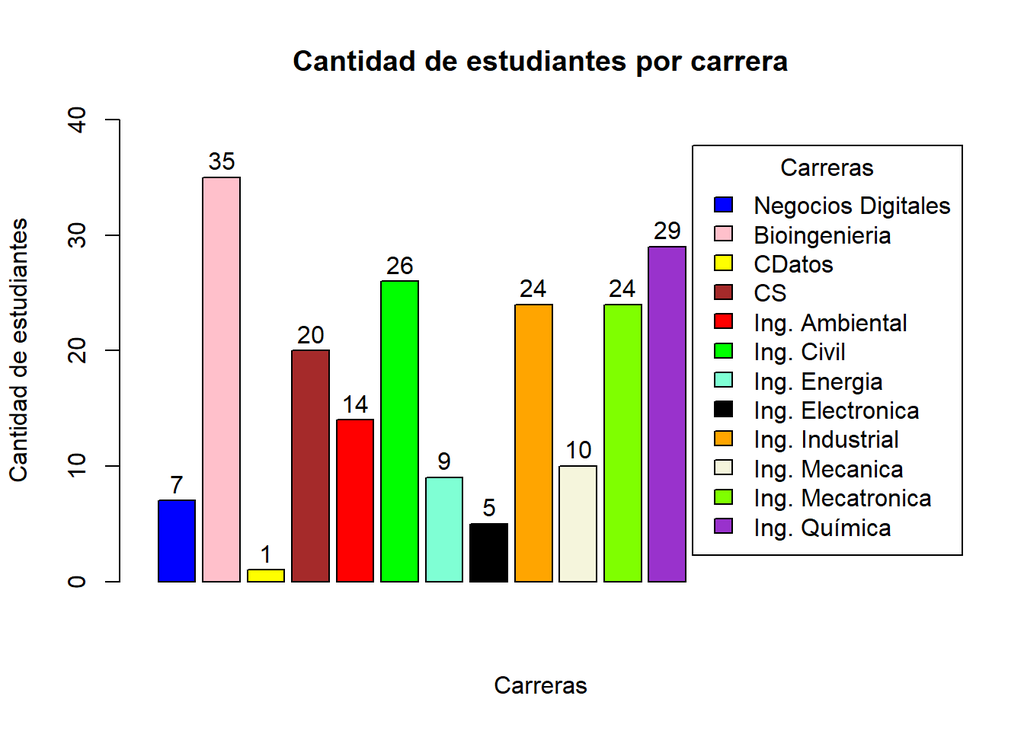

En la presente gráfica de barras se puede observar que existe una mayor cantidad de estudiantes encuestados en la carrera de Bioingeniería con un total de 35. Asimismo, la carrera que presenta una menor cantidad de encuestados es la de Ciencia de Datos con un total de 1 encuestado y ambas cantidades se toma con respecto del total de muestra.

## Analisis de la variable “Edad”

Variable de tipo cuantitativa discreta. Con la el comando ´sumary´se obtiene: mínimo, primer cuartil, mediana, media, tercer cuartil y máximo.

```r
summary(BDC$Edad)
```

```
##    Min. 1st Qu.  Median    Mean 3rd Qu.    Max.
##   17.00   18.00   19.00   19.34   20.00   33.00
```

```r
var(BDC$Edad,na.rm=T)  # varianza
```

```
## [1] 4.709263
```

```r
sd(BDC$Edad,na.rm=T)   # desviación estandar
```

```
## [1] 2.170084
```

```r
range(BDC$Edad) #RANGO
```

```
## [1] 17 33
```

```r
mean(BDC$Edad,na.rm=T)  # la media o promedio ( esto no mide la dispersión)
```

```
## [1] 19.34314
```

De ello la edad mínima en la muestra fue 17 años y la máxima 33. Asimismo, se interpreta que la edad promedio de los encuestados se aproxima a 19 años.

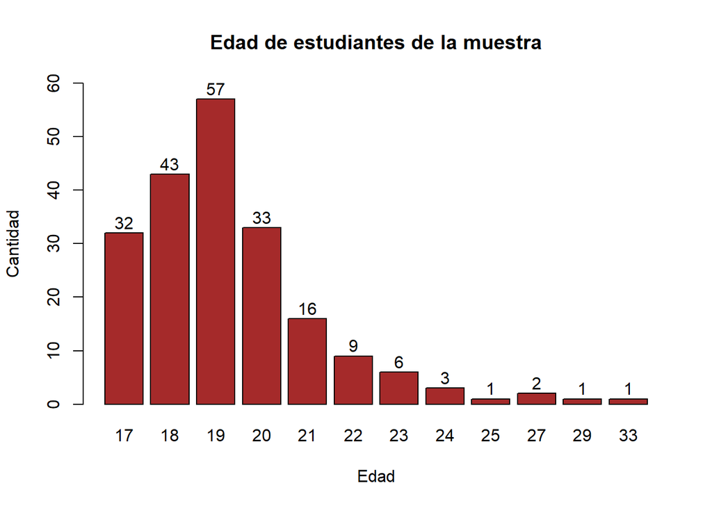

*Interpretación gráfica*: De la presente gráfica se puede interpretar que la mayor cantidad de estudiantes encuestados, siendo 57 el valor alcanzado, tiene en promedio 19 años. De la misma manera, se lograr visualizar que la menor cantidad de encuestados con una cantidad de 1 tienen en promedio 25, 29 y 33 años.

## Analisis de la variable “Sexo”

```r
library(plotrix)
```

Variable categórica nominal

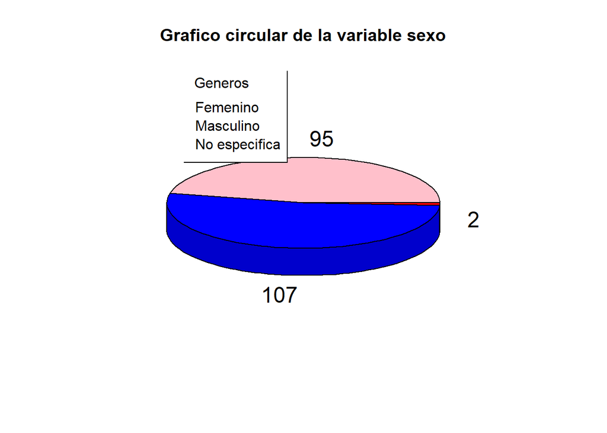

*Interpretación gráfica* La mayor cantidad de estudiantes que accedió a realizar la encuesta fueron del sexo masculino. Y 2 de los encuestados prefirió no decir su sexo.

```r
#La frecuencia muestral
table(BDC$Sexo)
```

```
##
##            Femenino           Masculino Prefiero no decirlo
##                  95                 107                   2
```

```r
#Frecuencia relativa
table(BDC$Sexo)*100/204
```

```
##
##            Femenino           Masculino Prefiero no decirlo
##          46.5686275          52.4509804           0.9803922
```

En tal sentido 95 encuestados son del sexo femenino y representa el 46.56 %, el sexo masculino con 107 encuestados lo que representa el 52. 45% de la población encuestada.

## Analisis de la variable “Distrito”

Variable categórica nominal La variable es una determinante en la investigación, pues depende del distrito de residencia el tiempo que toma en llegar a la universidad.

```r
#La frecuencia muestral
table(BDC$Distrito)
```

```
##
##                   Ancón             Ate vitarte                Barranco
##                       1                       6                      27
##                   Breña              Carabayllo              Chorrillos
##                       1                       4                      16
##             Cieneguilla                   Comas             El Agustino
##                       1                       9                       4
##           Independencia             Jesus María               La Molina
##                       1                       1                       8
##             La Victoria                    Lima                   Lince
##                       2                       9                       2
##              Los Olivos              Lurigancho                   Lurín
##                       5                       4                       2
##       Magdalena del Mar              Miraflores              Pachacamac
##                       2                       8                       1
##            Pueblo Libre           Puente Piedra                   Rímac
##                       6                       7                       2
##               San Borja              San Isidro  San Juan de Lurigancho
##                       4                       2                      15
##  San Juan de Miraflores    San Martín de Porres              San Miguel
##                       8                      12                       1
##             Santa Anita       Santiago de surco               Surquillo
##                       3                      15                       5
##       Villa el Salvador Villa María del Triunfo
##                       4                       6
```

```r
#Frecuencia relativa
table(BDC$Distrito)/204
```

```
##
##                   Ancón             Ate vitarte                Barranco
##             0.004901961             0.029411765             0.132352941
##                   Breña              Carabayllo              Chorrillos
##             0.004901961             0.019607843             0.078431373
##             Cieneguilla                   Comas             El Agustino
##             0.004901961             0.044117647             0.019607843
##           Independencia             Jesus María               La Molina
##             0.004901961             0.004901961             0.039215686
##             La Victoria                    Lima                   Lince
##             0.009803922             0.044117647             0.009803922
##              Los Olivos              Lurigancho                   Lurín
##             0.024509804             0.019607843             0.009803922
##       Magdalena del Mar              Miraflores              Pachacamac
##             0.009803922             0.039215686             0.004901961
##            Pueblo Libre           Puente Piedra                   Rímac
##             0.029411765             0.034313725             0.009803922
##               San Borja              San Isidro  San Juan de Lurigancho
##             0.019607843             0.009803922             0.073529412
##  San Juan de Miraflores    San Martín de Porres              San Miguel
##             0.039215686             0.058823529             0.004901961
##             Santa Anita       Santiago de surco               Surquillo
##             0.014705882             0.073529412             0.024509804
##       Villa el Salvador Villa María del Triunfo
##             0.019607843             0.029411765
```

Gráfico de la variable “Distrito”

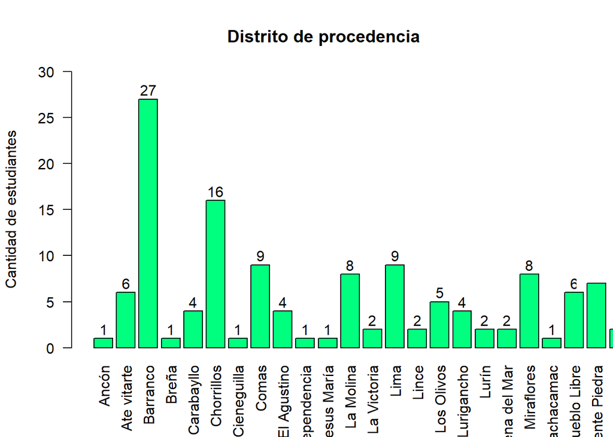

## Analisis de la variable “Buses”

Variable cuantitativa discreta

```r
summary(BDC$Buses)
```

```
##    Min. 1st Qu.  Median    Mean 3rd Qu.    Max.
##   0.000   1.000   2.000   1.662   2.000   4.000
```

```r
var(BDC$Buses,na.rm=T)  # varianza
```

```
## [1] 0.687989
```

```r
sd(BDC$Buses,na.rm=T)   # desviación estándar
```

```
## [1] 0.829451
```

```r
range(BDC$Buses) #RANGO
```

```
## [1] 0 4
```

```r
mean(BDC$Buses,na.rm=T)  # la media o promedio ( esto no mide la dispersión)
```

```
## [1] 1.661765
```

```r
CV<-(sd(BDC$Buses,na.rm=T)/mean(BDC$Buses,na.rm=T))*100   # coeficiente de variación.
CV
```

```
## [1] 49.91387
```

Se sabe que el numero minimo de buses que utilizan los estudiantes es 0, lo que significa que los estudiantes caminan para llegar a la universidad, tambien se conoce que la cantidad maxima de carros que utilizan los estudiantes es de 4, siendo el promedio 2 carros al dia.

ANALISIS  
Organizamos la información en un gráfico

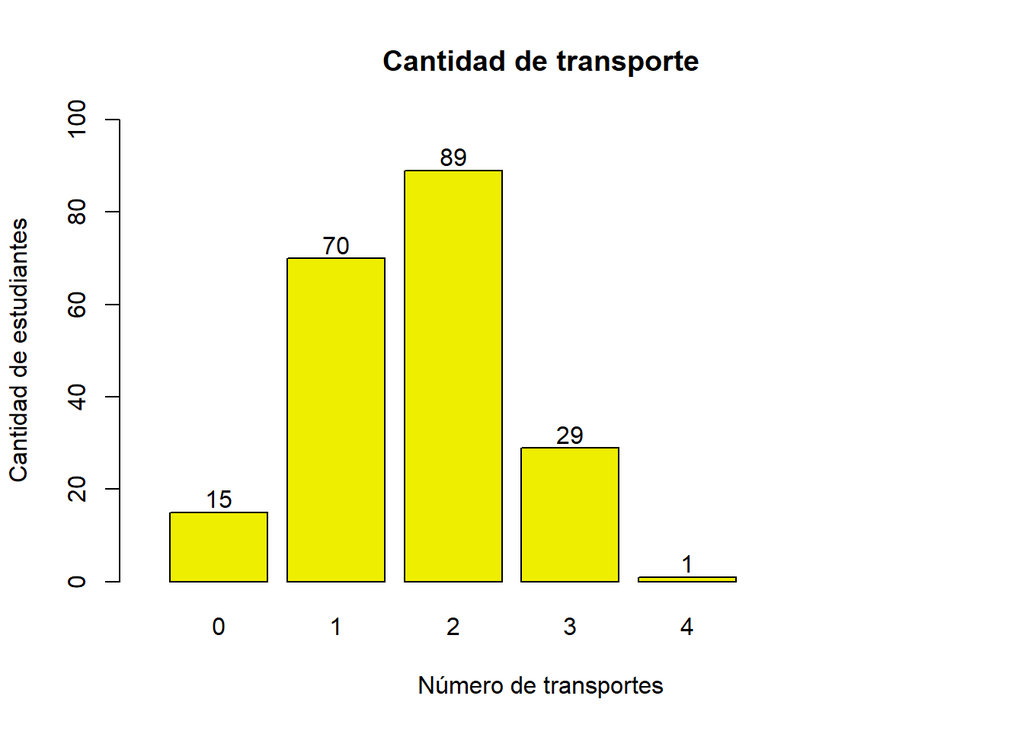

Mediante este gráfico se puede ver mejor lo detallado lineas arriba. Se observa que la mayor cantidad de la población encuestada utiliza 2 carros al dia para llegar a la univesidad.

## Analisis de la variable “TIEMPO”

Variable cuantitativa continua

```r
table(BDC$Tiempo)
```

```
##
##               10-15 min              10 minutos                   10min
##                       1                       1                       1
##                 2 horas               5 minutos    De 1 a 1 (1/2) hora.
##                      32                       1                      55
##      Entre 15 a 30 min.       Entre 2 a 3 horas Entre 30 min. a 1 hora.
##                      48                      18                      47
```

La mayor cantidad de personas demora entre 1h a 1h y 1/2 hora en llegar desde su casa a la universidad

```r
#saldos
rm(a)
```

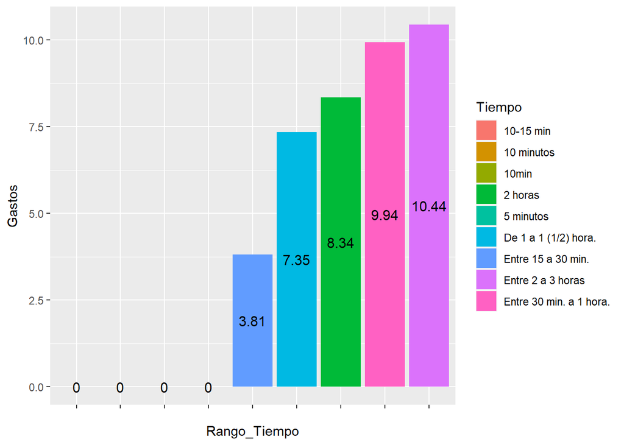

```r
a<-aggregate(Gasto ~ Tiempo, data = BDC, mean) #Para agrupar y quedarse solo con las variables gasto y tiempo

#SALDOS#-----medidas del grafico 500*400

g <- ggplot(a, aes(reorder(Tiempo ,Gasto),y=Gasto))+ylab("Gastos") +xlab("Rango_Tiempo")
g +geom_bar(stat="identity",aes(fill=Tiempo))+ geom_text(aes(label=round(Gasto,2)) ,colour = "black" , position = position_stack(vjust = 0.5),size =4)+ theme (axis.text.x = element_text(colour="White"))
```

Del siguiente gráfico se observa que las personas que demoran entre 2 a 3horas al dia en viajar hacia el centro de estudio son las personas que gastan en promedio 10.44 soles al día.

## Análisis de la variable gastos por carreras, dividido por sexo

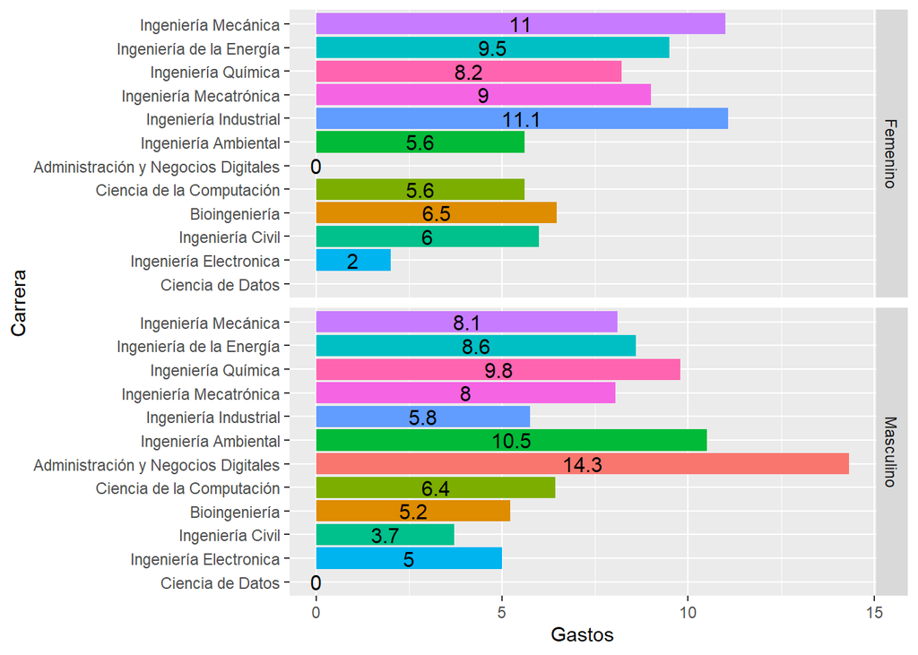

```r
#saldos
f_sexo <- filter(BDC,Sexo=="Femenino"|Sexo=="Masculino")
rm(a)
a<-aggregate(Gasto ~ Carrera+Sexo, data = f_sexo, mean) #Para agrupar y quedarse solo con las variables gasto y tiempo
a<-arrange(a, Gasto,Carrera)
#SALDOS#-----medidas del grafico 500*400

g1 <- ggplot(a, aes(reorder(Carrera ,Gasto),y=Gasto))+ylab("Gastos") +xlab("Carrera")
g1 +geom_bar(stat="identity",aes(fill=Carrera))+ geom_text(aes(label=round(Gasto,1)) ,colour = "black" , position = position_stack(vjust = 0.5),size =4)+coord_flip()+ theme (legend.position="none")+facet_grid( Sexo~.)
```

## Análisis de la variable gastos por ciclos, dividido por sexo

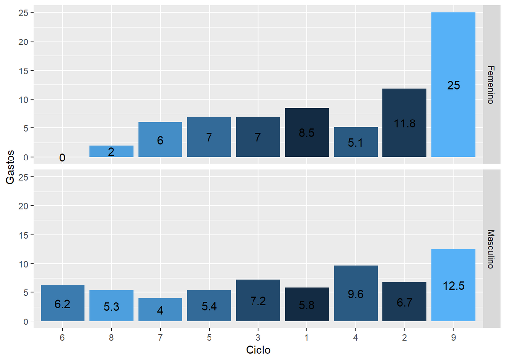

```r
#saldos
f_sexo <- filter(BDC,Sexo=="Femenino"|Sexo=="Masculino")
rm(a)
ab<-aggregate(Gasto ~ Ciclo+Sexo, data = f_sexo, mean) #Para agrupar y quedarse solo con las variables gasto y tiempo
ab<-arrange(ab, Gasto,Ciclo)

g2 <- ggplot(ab, aes(reorder(Ciclo ,Gasto),y=Gasto))+ylab("Gastos") +xlab("Ciclo")
g2 +geom_bar(stat="identity",aes(fill=Ciclo))+ geom_text(aes(label=round(Gasto,1)) ,colour = "black" , position = position_stack(vjust = 0.5),size =4)+ theme (legend.position="none")+facet_grid( Sexo ~ .)
```

## Analisis de la variable “Caminata”

Variable cuantitativa continua

```r
table(BDC$Caminata)
```

```
##
##  0  1  2  3  4  5  6  7  8  9 10 11 12 13 15 20 25
##  8  6  7  3  2 37  1  8  5  1 50  1  1  3 54 15  2
```

```r
summary(BDC$Caminata)
```

```
##    Min. 1st Qu.  Median    Mean 3rd Qu.    Max.
##    0.00    5.00   10.00   10.07   15.00   25.00
```

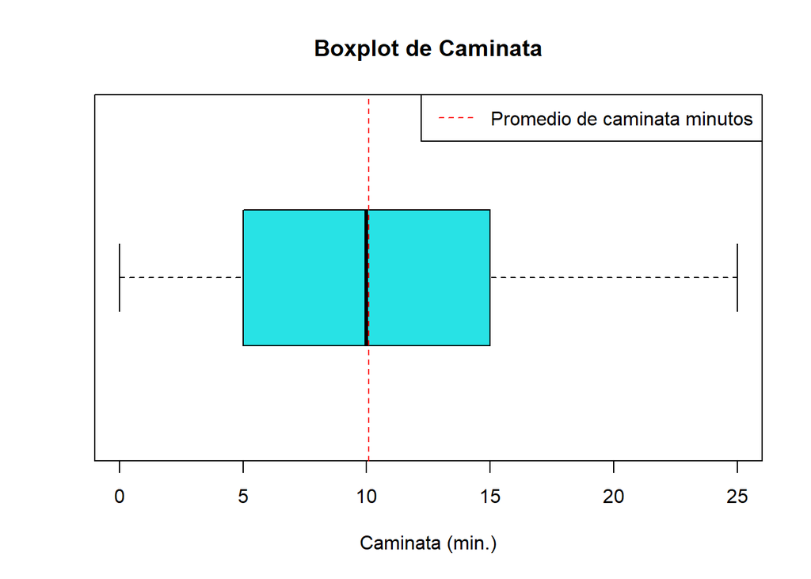

```r
boxplot(BDC$Caminata,horizontal = TRUE, main = "Boxplot de Caminata", xlab = "Caminata (min.)", col=5)
abline(v=mean(BDC$Caminata),col="red",lty=2)
legend("topright",legend = "Promedio de caminata minutos",col="red",lty=2)
```

- Comentario: Según el Diagrama de Cajas y Bigotes (Boxplot) se puede visualizar que el valor de la mediana también denominado quartil 2 (Q2) para el promedio de caminata de las personas encuestadas es de 10 minutos. Asimismo, el quartil inferior (Q1) presentó un valor de 5 minutos y el quartil superior (Q3) tiene un valor igual a 15 minutos. De la misma manera, se observa una diferencia en el rango intercuartil (distancia que separa Q1 y Q3) igual a 10 minutos. Los valores máximos y mínimos para nuestro diagrama son 25 y 0 minutos respectivamente.

## Analisis de la variable “Gasto”

Variable cuantitativa nominal

```r
table(BDC$Gasto)
```

```
##
##  0  1  2  3  4  5  6  7  8  9 10 11 12 15 16 20 25 30 35 40 50
## 22  3 15 15 19 28 17  9 14  4 27  4  6  7  1  5  1  2  2  1  2
```

```r
summary(BDC$Gasto)
```

```
##    Min. 1st Qu.  Median    Mean 3rd Qu.    Max.
##   0.000   3.000   5.500   7.397  10.000  50.000
```

```r
#Descriptores de Dispersión

range(BDC$Gasto) #Rango
```

```
## [1]  0 50
```

```r
var(BDC$Gasto) #Varianza
```

```
## [1] 57.47211
```

```r
sd(BDC$Gasto) #Desviación estandar
```

```
## [1] 7.581036
```

```r
#coefficient.variation(sd=sd(BDC$Gasto), avg = mean(BDC$Gasto)) #Coeficiente de variación
```

Se conoce que la variable gasto cuenta con los siguientes indicadores: - Rango = 50 - Varianza = 57,47 - Desviación estándar = 7,58

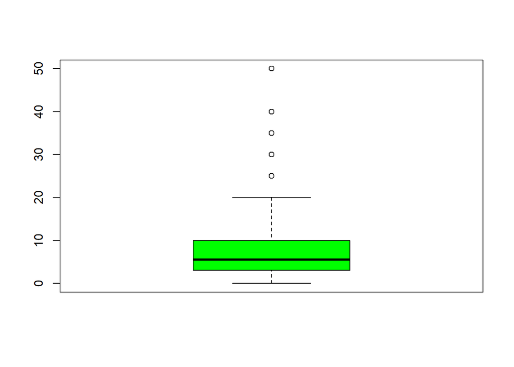

```r
boxplot(BDC$Gasto, col = "green")
```

## Analisis de la variable “Estrés”

Variable categórica ordinal

```r
#La frecuencia muestral
table(BDC$Estrés)
```

```
##
##  1  2  3  4  5
## 12 18 66 75 33
```

```r
#Frecuencia relativa
table(BDC$Estrés)/204
```

```
##
##          1          2          3          4          5
## 0.05882353 0.08823529 0.32352941 0.36764706 0.16176471
```

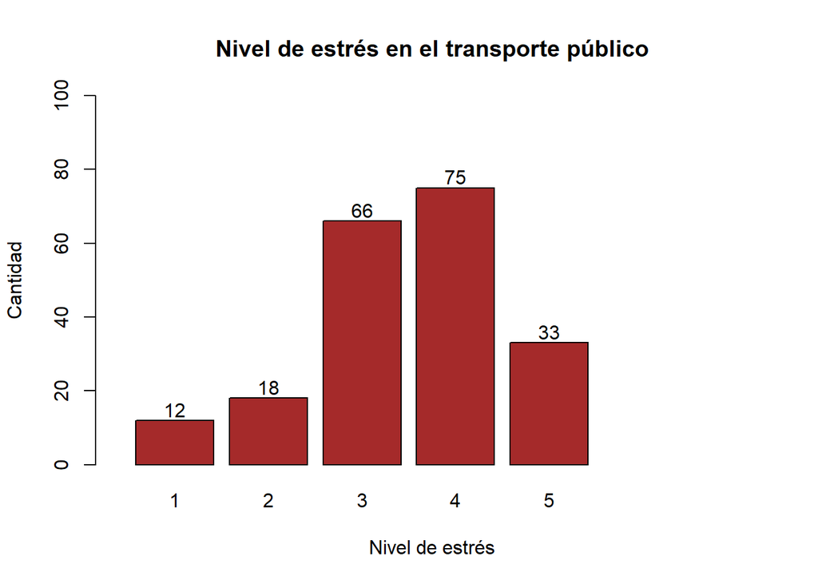

75 de los encuestados considera que el transporte público suma mucho(4) a su nivel de estrés.

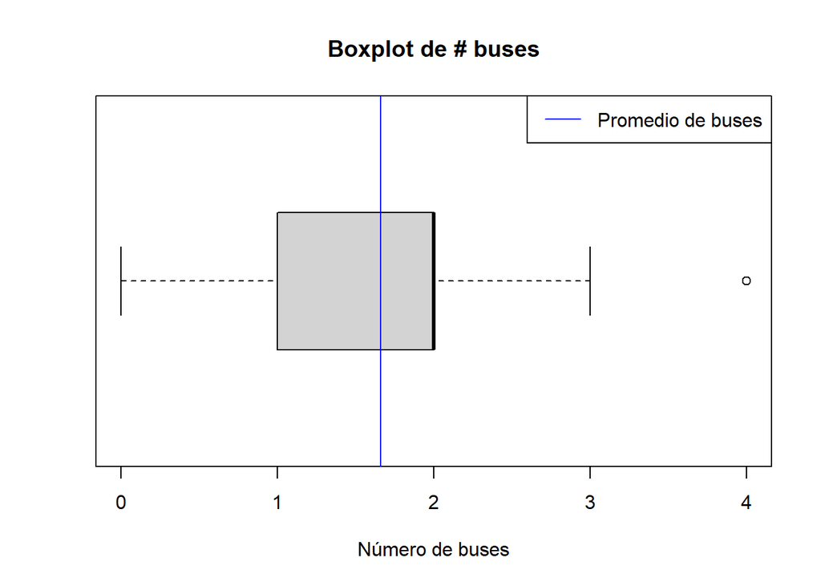

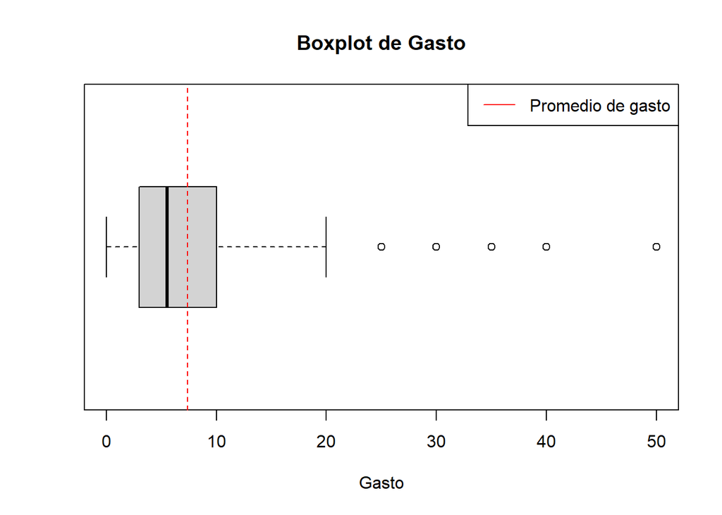

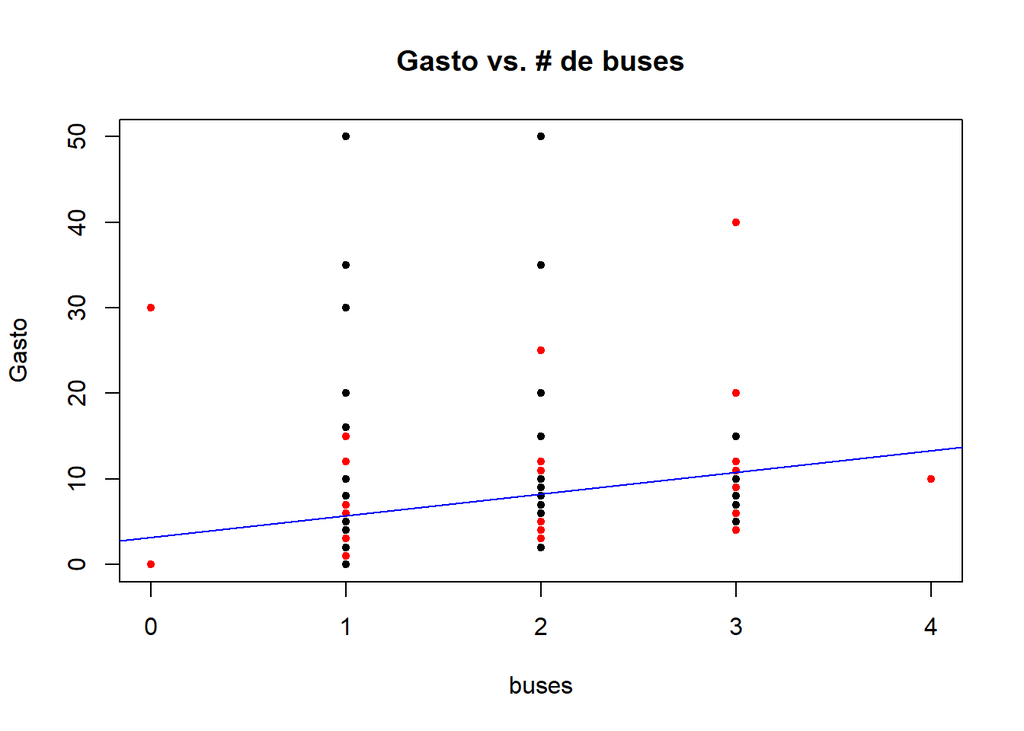

Del gráfico muestra la relación entre la cantidad de buses y el gasto que ello implica.

[figure not shown]

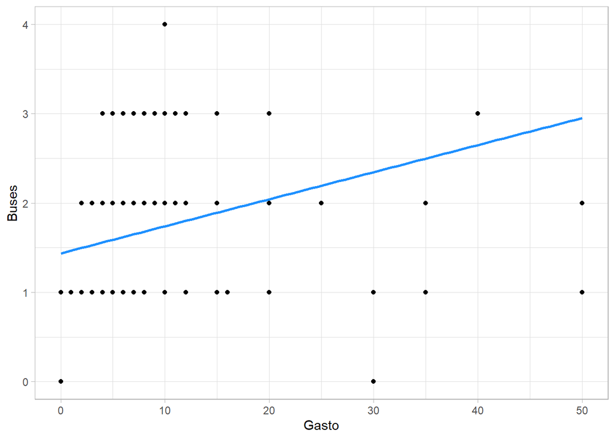

```
##
## Call:
## lm(formula = BDC$Gasto ~ BDC$Buses)
##
## Residuals:
##    Min     1Q Median     3Q    Max
## -6.783 -3.253 -2.253  0.864 44.277
##
## Coefficients:
##             Estimate Std. Error t value Pr(>|t|)
## (Intercept)   3.1922     1.1471   2.783   0.0059 **
## BDC$Buses     2.5304     0.6179   4.095 6.11e-05 ***
## ---
## Signif. codes:  0 '***' 0.001 '**' 0.01 '*' 0.05 '.' 0.1 ' ' 1
##
## Residual standard error: 7.303 on 202 degrees of freedom
## Multiple R-squared:  0.07665,    Adjusted R-squared:  0.07208
## F-statistic: 16.77 on 1 and 202 DF,  p-value: 6.109e-05
```

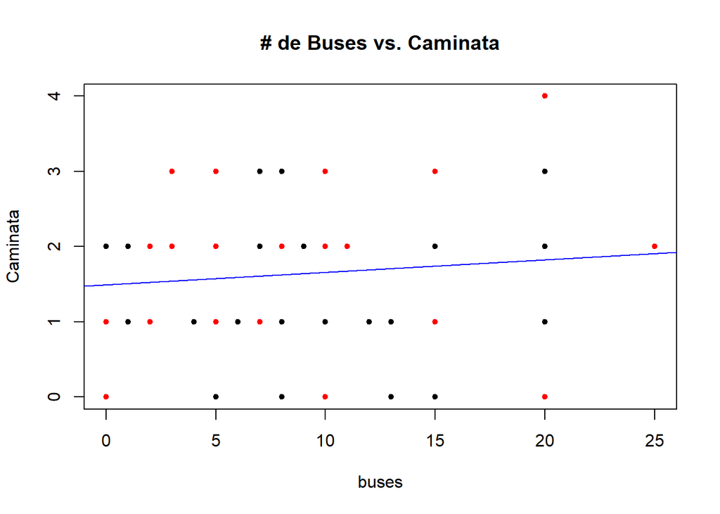

```r
#Relación entre variables 2:
regre0<-plot(BDC$Buses~BDC$Caminata,pch=20,col=c("black","red"),main="# de Buses vs. Caminata",xlab="buses",ylab="Caminata")
abline(lm(BDC$Buses~BDC$Caminata),col="blue",lty=1)
```

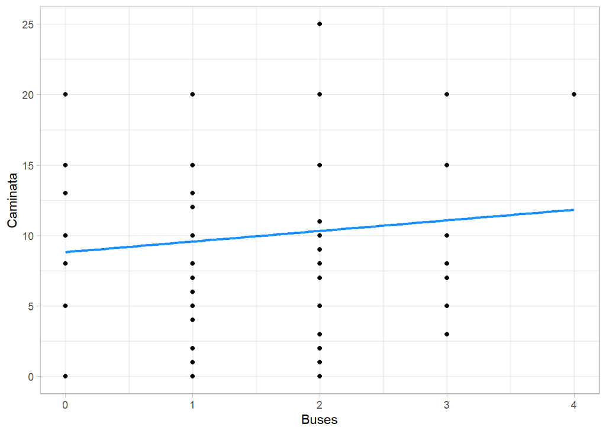

```r
regre11<-lm(BDC$Buses~BDC$Caminata)

ggplot(BDC, aes(x=Buses,y=Caminata))+geom_point()+
geom_smooth(method='lm', formula=y~x, se=FALSE, col='dodgerblue1')+theme_light()
```

```r
summary(regre11)#Ecuación: Y = B0 + B1*X + E
```

```
##
## Call:
## lm(formula = BDC$Buses ~ BDC$Caminata)
##
## Residuals:
##     Min      1Q  Median      3Q     Max
## -1.8269 -0.6148  0.2563  0.3977  2.1732
##
## Coefficients:
##              Estimate Std. Error t value Pr(>|t|)
## (Intercept)   1.49423    0.11964   12.49   <2e-16 ***
## BDC$Caminata  0.01663    0.01040    1.60    0.111
## ---
## Signif. codes:  0 '***' 0.001 '**' 0.01 '*' 0.05 '.' 0.1 ' ' 1
##
## Residual standard error: 0.8263 on 202 degrees of freedom
## Multiple R-squared:  0.01251,    Adjusted R-squared:  0.007624
## F-statistic:  2.56 on 1 and 202 DF,  p-value: 0.1112
```

```r
#BO:1.49423
#B1:0.01663
#E:0.8263
```

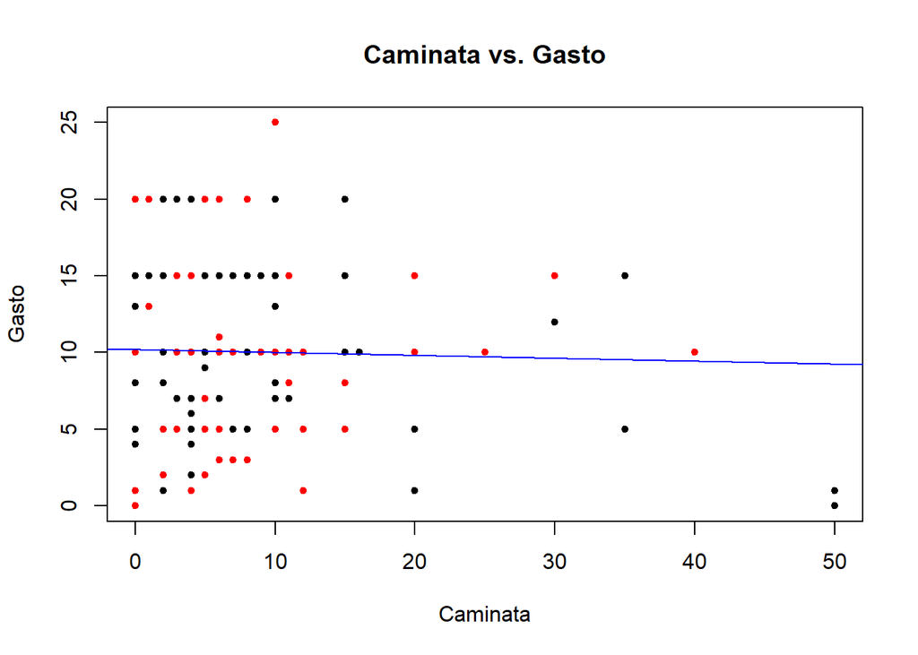

```r
#Relación entre variables 3:
regre21<-plot(BDC$Caminata~BDC$Gasto,pch=20,col=c("black","red"),main="Caminata vs. Gasto",xlab="Caminata",ylab="Gasto")
abline(lm(BDC$Caminata~BDC$Gasto),col="blue",lty=1)
```

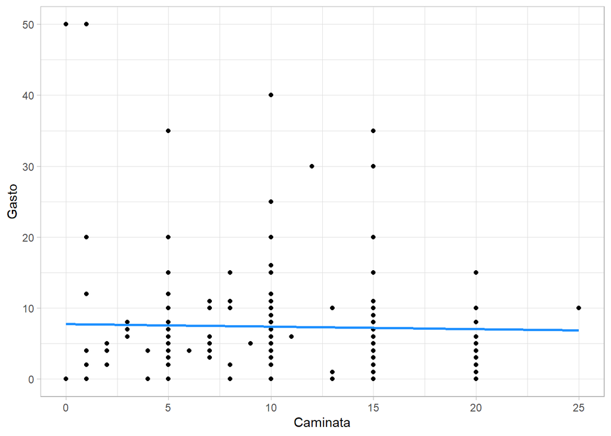

```r
regre12<-lm(BDC$Caminata~BDC$Gasto)

ggplot(BDC, aes(x=Caminata,y=Gasto))+geom_point()+
geom_smooth(method='lm', formula=y~x, se=FALSE, col='dodgerblue1')+theme_light()
```

```r
summary(regre12)#Ecuación: Y = B0 + B1*X + E
```

```
##
## Call:
## lm(formula = BDC$Caminata ~ BDC$Gasto)
##
## Residuals:
##      Min       1Q   Median       3Q      Max
## -10.2143  -5.0335  -0.1001   4.8809  14.9760
##
## Coefficients:
##             Estimate Std. Error t value Pr(>|t|)
## (Intercept) 10.21425    0.54754  18.655   <2e-16 ***
## BDC$Gasto   -0.01902    0.05176  -0.368    0.714
## ---
## Signif. codes:  0 '***' 0.001 '**' 0.01 '*' 0.05 '.' 0.1 ' ' 1
##
## Residual standard error: 5.591 on 202 degrees of freedom
## Multiple R-squared:  0.0006684,  Adjusted R-squared:  -0.004279
## F-statistic: 0.1351 on 1 and 202 DF,  p-value: 0.7136
```

```r
#BO:10.21425
#B1:-0.01902
#E:5.591
```

# ANÁLISIS PROBABILÍSTICO

## Probabilidad 1

Generando una tabla de probabilidades para seleccionar a un estudiante de una carrera específica y de un ciclo específico

```r
p_carrera <- select(BDC,Carrera)
p_carrera %>%
  group_by(Carrera) %>%
  summarise(n = n()) %>%
  mutate(proporcion = n / sum(n), porciento = round(proporcion*100,2))
```

| Carrera | n | proporcion | porciento |
| --- | --- | --- | --- |
| Administración y Negocios Digitales | 7 | 0.034313725 | 3.43 |
| Bioingeniería | 35 | 0.171568627 | 17.16 |
| Ciencia de Datos | 1 | 0.004901961 | 0.49 |
| Ciencia de la Computación | 20 | 0.098039216 | 9.80 |
| Ingeniería Ambiental | 14 | 0.068627451 | 6.86 |
| Ingeniería Civil | 26 | 0.127450980 | 12.75 |
| Ingeniería Electronica | 5 | 0.024509804 | 2.45 |
| Ingeniería Industrial | 24 | 0.117647059 | 11.76 |
| Ingeniería Mecatrónica | 24 | 0.117647059 | 11.76 |
| Ingeniería Mecánica | 10 | 0.049019608 | 4.90 |

[output cut: 2 more lines]

```r
p_ciclo <- select(BDC,Ciclo)
p_ciclo %>%
  group_by(Ciclo) %>%
  summarise(n = n()) %>%
  mutate(proporcion = n / sum(n), porciento = round(proporcion*100,2))
```

| Ciclo | n | proporcion | porciento |
| --- | --- | --- | --- |
| 1 | 26 | 0.12745098 | 12.75 |
| 2 | 32 | 0.15686275 | 15.69 |
| 3 | 87 | 0.42647059 | 42.65 |
| 4 | 25 | 0.12254902 | 12.25 |
| 5 | 14 | 0.06862745 | 6.86 |
| 6 | 6 | 0.02941176 | 2.94 |
| 7 | 3 | 0.01470588 | 1.47 |
| 8 | 7 | 0.03431373 | 3.43 |
| 9 | 4 | 0.01960784 | 1.96 |

```r
p_cica <- select(BDC,Carrera|Ciclo)
f_cica <- filter(p_cica,Carrera=="Ingeniería Química",Ciclo=="9")
f_cica
```

| Carrera | Ciclo |
| --- | --- |

|  | 1 | 2 | 3 | 4 | 5 | 6 | 7 | 8 | 9 | TOTAL |
| --- | --- | --- | --- | --- | --- | --- | --- | --- | --- | --- |
| Negocios Digitales | 0.0000 | 0.0147 | 0.0000 | 0.0196 | 0.0000 | 0.0000 | 0.0000 | 0.0000 | 0.0000 | 0,0343 |
| Bioingeniería | 0.0392 | 0.0196 | 0.0882 | 0.0049 | 0.0098 | 0.0000 | 0.0000 | 0.0049 | 0.0049 | 0,1716 |
| Ciencia de datos | 0.0000 | 0.0000 | 0.0000 | 0.0049 | 0.0000 | 0.0000 | 0.0000 | 0.0000 | 0.0000 | 0.0049 |
| Computer Science | 0.0098 | 0.0196 | 0.0343 | 0.0147 | 0.0049 | 0.0098 | 0.0000 | 0.0049 | 0.0000 | 0,0980 |
| Ing. Ambiental | 0.0098 | 0.0000 | 0.0441 | 0.0098 | 0.0000 | 0.0000 | 0.0000 | 0.0049 | 0.0000 | 0,0686 |
| Ing. Civil | 0.0098 | 0.0098 | 0.0686 | 0.0147 | 0.0147 | 0.0000 | 0.0049 | 0.0000 | 0.0049 | 0,1275 |
| Ing. de la Energía | 0.0098 | 0.0049 | 0.0147 | 0.0000 | 0.0049 | 0.0049 | 0.0000 | 0.0000 | 0.0049 | 0,0441 |
| Ing. Electrónica | 0.0049 | 0.0049 | 0.0000 | 0.0049 | 0.0049 | 0.0000 | 0.0000 | 0.0049 | 0.0000 | 0,0245 |
| Ing. Industrial | 0.0098 | 0.0147 | 0.0634 | 0.0098 | 0.0049 | 0.0049 | 0.0000 | 0.0049 | 0.0049 | 0,1176 |
| Ing. Mecánica | 0.0196 | 0.0049 | 0.0098 | 0.0000 | 0.0098 | 0.0049 | 0.0000 | 0.0000 | 0.0000 | 0,0490 |
| Ing. Mecatrónica | 0.0049 | 0.0539 | 0.0294 | 0.0196 | 0.0049 | 0.0000 | 0.0000 | 0.0049 | 0.0000 | 0,1176 |
| Ing. Química | 0.0098 | 0.0098 | 0.0735 | 0.0196 | 0.0098 | 0.0049 | 0.0098 | 0.0049 | 0.0000 | 0,1422 |
| TOTAL | 0.1275 | 0.1569 | 0.4265 | 0.1225 | 0.0686 | 0.0294 | 0.0147 | 0.0343 | 0.0196 | 1,0000 |

## Probabilidad 2

Probabilidad de seleccionar 1 alumno de la carrera de bioingeniaría

```r
bio=35/204
bio
```

```
## [1] 0.1715686
```

```r
porbio=bio*100
round(porbio,2)
```

```
## [1] 17.16
```

P(a)= # de casos que satisfacen la condición / # de casos posibles Espacio muestral: 204 estudiantes encuestados Respuesta: Se obtiene una probabilidad de 17.16% para seleccionar a 1 alumno de la carrera de bioingeniería

## Probabilidad 3

Probabilidad de seleccionar 1 alumnos de Ciencia de la Computación o Ingeniería Industrial

```r
CoI= 44/204
CoI
```

```
## [1] 0.2156863
```

```r
porCoI=CoI*100
round(porCoI,2)
```

```
## [1] 21.57
```

Respuesta: Se obtiene una probabilidad de 21,57% para seleccionar a un alumno que sea de la carrerade Ciencia de la Computació o de Ingeniería Industrial

## Probabilidad 4

De una encuesta realizada a un grupo de estudiantes de la Universidad de Ingeniería y Tecnología se sabe que el promedio de medios de transporte para llegar a la universidad es de 2 en un día. Sabiendo que el número de medios de transporte siguen una distribución de Poisson, calcular:* ¿Cuál es la probabilidad de que solo se necesiten 3 medios de transporte en 1 día? Como se trata de una distribución de Poisson esta se aplica en variables del tipo discreta los cuales se analizan de la siguiente forma: x = numero de medios de transporte para llegar a la universidad en un día u = 2 Formulamos P(X=x) —> P(x=3)  
hallando lambd: se utiliza 2 vehículos por día, la pregunta es acerca de 1 dia. lambda = 2x1 = 2 dpois()

```r
dpois(3,2)
```

```
## [1] 0.180447
```

Porcentaje:

```r
dpois(3,2)*100
```

```
## [1] 18.0447
```

Respuesta: La probabilidad de que solo usen tres medios de transporte es de 0.1804.Asimismo en porcentaje es aproximadamente 18.04%.

## Probabilidad 5

```r
dbinom(5,10,0.265)
```

```
## [1] 0.07064259
```

Porcentaje:

```r
dbinom(5,10,0.265)*100
```

```
## [1] 7.064259
```

Respuesta: La probabilidad de que los alumnos demoren 1 a 1 (1/2) hora es de 0.071.Asimismo en porcentaje es aproximadamente 7.06%.

## Probabilidad 6

De un grupo de 204 estudiantes encuestados de la Universidad de Ingeniería y Tecnología. Se obtuvo que 89 de ellos utilizan el metropolitano como medio de transporte para movilizarse hasta el campus universitario. ¿Cuál es la probabilidad de que el cuarto encuestado no necesite movilizarse con este medio de transporte?

Solución: Cuando aplicamos una distribución geométrica debemos definir : - *Éxito*: No utilice el metropolitano para transportarse - *Fracaso* : que utilice el metropolitano para transportarse

Realizamos el calculó de la probabilidad de que los estudiantes encuestados no utilizan el metropolitano como transporte *Datos* Total = Cantidad total de estudiantes encuestados SM: Cantidad de estudiantes encuestados que utilizan metropolitano NM: Cantidad de estudiantes encuestados que no usan el metropolitano Total = 204 SM =89 —> *Este dato lo sacamos de la data* NM= 204-89 = 115 P(x)=(NM/Total) P(x)=(115/204)

Encontramos el número de fracasos que antes de alcanzar por primera vez el éxito según lo que nos piden en el problema ya que en R estudio se necesita de este parámetro.

*Aplicando la función* “dgeom”:

```r
dgeom(3,(115/204))
```

```
## [1] 0.04681092
```

“Aplicando porcentaje”

```r
dgeom(3,(115/204))*100
```

```
## [1] 4.681092
```

Respuesta:  
La probabilidad de que el cuarto encuestado no necesite movilizarte con el Metropolitano es 0.0468 aproximadamente. Asimismo, presenta un porcentaje de 4.68%

## Probabilidad 7

De una encuesta realizada a un grupo de estudiantes de la Universidad de Ingenería y Tecnología se sabe que la de edad promedio de los encuestados es 19. Si la edad de estos encuestados se rige bajo una distribución exponencial: **¿Cuál es la probabilidad de que la edad de los encuestados se a lo más 20?** Como se trata de una distribución exponencial esta se aplica en variables del tipo continua los cuales se analizarán de la siguiente forma: b = Edad promedio de los estudiantes encuestados b = 19 años *Formulamos* P(x<=a) —> P(x<=20) pexp()

```r
pexp(20,1/19)
```

```
## [1] 0.6509819
```

Porcentaje:

```r
pexp(20,1/19)*100
```

```
## [1] 65.09819
```

Respuesta: La probabilidad de que la edad de los encuestados se a lo más 20 es de 0.65.Asimismo en porcentaje es aproximadamente 65.09%.

## Probabilidad 8

**¿Cuál es la probabilidad de que los encuestados tengan una edad entre 17 y 18 años?** Como se trata de una distribución exponencial esta se aplica en variables del tipo continua los cuales se analizarán de la siguiente forma:

p(b<= x <=a) —> p(17<=x<=18)

```r
pexp(18,1/19)-pexp(17,1/19)
```

```
## [1] 0.02095504
```

```r
(pexp(18,1/19)-pexp(17,1/19))*100
```

```
## [1] 2.095504
```

Respuesta: La probabilidad de que los encuestados tengan una edad entre 17 y 18 años es de 0.0209. Con un porcentaje aproximado de 2.09%

## Probabilidad 9

```r
dpois(7,10)
```

```
## [1] 0.09007923
```

Porcentaje:

```r
dpois(7,10)*100
```

```
## [1] 9.007923
```

# BIBLIOGRAFÍA

- Toda la presente información fue obtenida por el material de estudio brindado en el curso de Estadística y Probabilidades 1, del periodo académico 2022-2.